# AML - Phase 3: Predictive Modeling & Validation

Autor:in

Luca Manna

Veröffentlichungsdatum

5. Juni 2026

In dieser Phase werden **prädiktive Modelle** trainiert und validiert. Ziel ist es, Kunden zu identifizieren, die am wahrscheinlichsten eine Kreditkarte akzeptieren.

**Modelle:** 1. **Baseline:** Logistische Regression mit 5 Features (Aufgabenanforderung) 2. **Handcrafted:** Logistische Regression mit ~65 handgefertigten Features (Baseline + Static + Behavioral + Window, ohne tsfresh) 3. **Random Forest** — Alle ~1130 Features (inkl. deduplizierte tsfresh) 4. **HistGBT (balanced)** — Alle ~1130 Features, mit class_weight 5. **XGBoost** — Alle ~1130 Features, mit `scale_pos_weight` zur Behandlung der Klassen-Imbalance

Die zuvor evaluierte HistGBT-Variante ohne `class_weight` wurde entfernt: Sie war zu ihrer balancierten Schwester weitgehend redundant (identische Architektur, lediglich unterschiedliche Loss-Gewichtung) und brachte keinen substanziellen Mehrwert. Stattdessen liefert **XGBoost** echte Architektur-Diversität (eigener Boosting-Algorithmus, andere Regularisierung, eigenes Tree-Building) im Ensemble-Vergleich.

**Methodik:** StratifiedKFold (k=5) Cross-Validation auf dem Training-Set, finale Evaluation auf dem gehaltenen Test-Set. `class_weight="balanced"` bzw. `scale_pos_weight` wo angegeben.

```python
import atexit
import sys
import warnings

# ConvergenceWarning früh importieren und Filter setzen, bevor die schweren
# Third-Party-Pakete geladen werden, damit deren Import-Warnings unterdrückt werden.
from sklearn.exceptions import ConvergenceWarning

# Gezielt unterdrücken statt global — unerwartete Warnings bleiben sichtbar
warnings.filterwarnings(
    "ignore", category=ConvergenceWarning
)  # LogReg: max_iter ggf. knapp in einzelnen CV-Folds
warnings.filterwarnings(
    "ignore", category=FutureWarning
)  # sklearn/XGBoost API-Deprecations
warnings.filterwarnings(
    "ignore", category=UserWarning, module="wandb"
)  # wandb-interne Meldungen

import matplotlib.pyplot as plt
import numpy as np
import pandas as pd
import seaborn as sns
import shap
import wandb
from sklearn.ensemble import (
    HistGradientBoostingClassifier,
    RandomForestClassifier,
)
from sklearn.inspection import permutation_importance
from sklearn.linear_model import LogisticRegression
from sklearn.model_selection import (
    GridSearchCV,
    RandomizedSearchCV,
    cross_validate,
)
from sklearn.pipeline import Pipeline as SKPipeline
from xgboost import XGBClassifier

sys.path.insert(0, "..")

from src.data import PATH_FEATURE_MATRIX, RANDOM_STATE, set_plot_style
from src.modeling import (
    N_ITER_RANDOM_SEARCH,
    SCORING_METRICS,
    SCORING_PRIMARY,
    TOP_N_PERCENTILES,
    build_pipeline,
    check_param_at_boundary,
    compare_top_n_lists,
    compute_top_n_list,
    evaluate_on_test,
    get_cv_splitter,
    get_feature_sets,
    plot_confusion_matrices,
    plot_feature_importance,
    plot_lift_curve,
    plot_pr_curves,
    plot_roc_curves,
)

set_plot_style()
print("Setup complete.")
```

```
Setup complete.
```

```python
run = wandb.init(
    project="aml-credit-card-affinity",
    name="phase3-modeling-v2",
    config={"random_state": RANDOM_STATE, "cv_folds": 5},
    reinit="finish_previous",
    settings=wandb.Settings(save_code=False),
)

# Safety: finish run even if kernel crashes or is interrupted
atexit.register(lambda: wandb.finish(quiet=True))
```

[output not shown]

Tracking run with wandb version 0.25.1

Run data is saved locally in `/Users/lucamanna/Documents/00_Coding/fhnw/06_AngewandteDataScience/aml/aml/notebooks/wandb/run-20260605_214540-lv6yg1wh`

Syncing run **[phase3-modeling-v2](https://wandb.ai/mannaluca02-fachhochschule-nordwestschweiz-fhnw/aml-credit-card-affinity/runs/lv6yg1wh)** to [Weights & Biases](https://wandb.ai/mannaluca02-fachhochschule-nordwestschweiz-fhnw/aml-credit-card-affinity) ([docs](https://wandb.me/developer-guide))

View project at https://wandb.ai/mannaluca02-fachhochschule-nordwestschweiz-fhnw/aml-credit-card-affinity

View run at https://wandb.ai/mannaluca02-fachhochschule-nordwestschweiz-fhnw/aml-credit-card-affinity/runs/lv6yg1wh

```
<function __main__.<lambda>()>
```

# 1 Daten laden & Train/Test Split

```python
fm = pd.read_parquet(PATH_FEATURE_MATRIX)
print(f"Feature-Matrix: {fm.shape[0]} Accounts × {fm.shape[1]} Spalten")
print(f"Target-Verteilung:\n{fm['target'].value_counts().to_string()}")
print(f"Split-Verteilung:\n{fm['split'].value_counts().to_string()}")
```

```
Feature-Matrix: 3893 Accounts × 1133 Spalten
Target-Verteilung:
target
0    3353
1     540
Split-Verteilung:
split
train    3111
test      782
```

```python
# Train/Test Split (vordefiniert aus Phase 2)
train_mask = fm["split"] == "train"
test_mask = fm["split"] == "test"

feature_sets = get_feature_sets(fm)
print(f"Feature Sets:")
for name, cols in feature_sets.items():
    print(f"  {name}: {len(cols)} Features")

# Prepare X/y
X_train_all = fm.loc[train_mask, feature_sets["all_features"]].copy()
X_test_all = fm.loc[test_mask, feature_sets["all_features"]].copy()
y_train = fm.loc[train_mask, "target"].astype(int)
y_test = fm.loc[test_mask, "target"].astype(int)
test_ids = fm.loc[test_mask, "account_id"].values

print(f"\nTrain: {len(y_train)} ({y_train.sum()} positiv, {y_train.mean():.1%})")
print(f"Test:  {len(y_test)} ({y_test.sum()} positiv, {y_test.mean():.1%})")

cv = get_cv_splitter()
```

```
Feature Sets:
  baseline: 5 Features
  static_all: 20 Features
  handcrafted: 64 Features
  all_features: 1130 Features

Train: 3111 (431 positiv, 13.9%)
Test:  782 (109 positiv, 13.9%)
```

# 2 Metrikwahl: Warum ROC-AUC primär und AP gleichwertig

**Klassenungleichgewicht.** Die Zielvariable hat eine Prävalenz von rund 13 % (vgl. Train/Test-Verteilung oben). Damit liegt eine *moderate* Imbalance vor, stark genug um die Wahl der Evaluationsmetrik zur kritischen Designentscheidung zu machen, aber nicht so extrem, dass Accuracy oder F1 grundsätzlich unbrauchbar wären. Bei ~13 % Positivrate würde ein triviales “alles negativ”-Modell bereits 87 % Accuracy erzielen, ohne einen einzigen Käufer zu identifizieren. Accuracy scheidet als Hauptmetrik daher aus.

**ROC-AUC als Hauptmetrik.** Wir verwenden ROC-AUC (`SCORING_PRIMARY = "roc_auc"`) als Optimierungsziel für Hyperparameter-Tuning und Modellvergleich. Die Metrik ist schwellenwert-unabhängig, bounded auf [0.5, 1] für nicht-triviale Klassifikatoren und besitzt eine **direkte Ranking-Interpretation**: ROC-AUC ist die Wahrscheinlichkeit, dass ein zufällig gewählter Käufer einen höheren Score erhält als ein zufällig gewählter Nicht-Käufer. Diese Lesart deckt sich exakt mit der Geschäftsanforderung: Wir wollen Kunden für eine Top-N%-Kampagne **sortieren**, nicht zwingend einen Hard-Cutoff treffen. Damit ist ROC-AUC anwendungsnah und nicht bloss eine technische Konvention (vgl. Fawcett, 2006).

**Average Precision (PR-AUC) als gleichwertige zweite Metrik.** ROC-AUC hat bei imbalancierten Daten einen bekannten Schwachpunkt: Da die Bewertung der Negativklasse in die Berechnung einfliesst, können ROC-Kurven bei einem grossen Anteil an Nicht-Käufern zu optimistisch wirken. Die **Precision-Recall-Kurve** fokussiert dagegen ausschliesslich auf die Positivklasse und ist daher informativer, sobald die positive Klasse selten ist. Average Precision (= Fläche unter der PR-Kurve) wird in diesem Notebook **gleichberechtigt** zu ROC-AUC berichtet, in den CV-Vergleichstabellen, im Bar-Chart neben ROC-AUC und in der finalen Evaluations-Tabelle (vgl. Davis & Goadrich, 2006).

**Konsequenz für dieses Projekt.** Beide Metriken werden CV- und Test-seitig berichtet. ROC-AUC bleibt das Optimierungsziel im `RandomizedSearchCV` (Single-Metric Search), aber AP wird in allen Vergleichstabellen und Plots gleichwertig geführt. **Tie-Breaker-Regel:** Falls zwei Modelle bei ROC-AUC praktisch gleichauf liegen, entscheidet die schwächere Metrik der beiden (AP), um auf die Positivklasse zu fokussieren, wobei die Anwendung als Ranking-Problem (Top-N% Kontaktliste) den Primat von ROC-AUC rechtfertigt.

**Sekundäre Metriken.** Zusätzlich werden F1, Precision und Recall bei Default-Threshold 0.5 berichtet, um die Klassifikationsleistung an einem konkreten Cutoff zu charakterisieren. Geschäftsrelevant sind ausserdem **Lift@10 %** und **Precision@Top-N %**, da diese direkt den ökonomischen Nutzen einer priorisierten Kampagnenliste widerspiegeln und im Deliverable-Teil weiter unten ausgewiesen werden.

# 3 Baseline-Modell: Logistische Regression (5 Features)

Die Aufgabenstellung fordert ein Baseline-Modell mit **logistischer Regression** und den Features: Alter, Geschlecht, Region (Durchschnittslohn), Vermögen (letzter Saldo) und Umsatz.

```python
baseline_cols = feature_sets["baseline"]
print("Baseline-Features:", baseline_cols)

X_train_bl = X_train_all[baseline_cols]
X_test_bl = X_test_all[baseline_cols]

# GridSearch over regularization strength C
param_grid_logreg = {"model__C": [0.001, 0.01, 0.1, 1.0, 10.0, 100.0]}

pipe_bl = build_pipeline(
    LogisticRegression(
        class_weight="balanced",
        solver="lbfgs",
        max_iter=1000,
        random_state=RANDOM_STATE,
    ),
    scale=True,
)

gs_bl = GridSearchCV(
    pipe_bl,
    param_grid_logreg,
    scoring=SCORING_PRIMARY,
    cv=cv,
    n_jobs=-1,
    refit=True,
)
gs_bl.fit(X_train_bl, y_train)

print(f"Bester C: {gs_bl.best_params_['model__C']}")
print(f"Beste CV ROC-AUC: {gs_bl.best_score_:.4f}")

# CV metrics for the best model
cv_bl = cross_validate(
    gs_bl.best_estimator_,
    X_train_bl,
    y_train,
    scoring=SCORING_METRICS,
    cv=cv,
    n_jobs=-1,
)
print("\nCV-Metriken (Baseline):")
for metric in SCORING_METRICS:
    vals = cv_bl[f"test_{metric}"]
    print(f"  {metric}: {vals.mean():.4f} ± {vals.std():.4f}")
```

```
Baseline-Features: ['age_at_event', 'gender', 'district_avg_salary', 'balance_last', 'turnover']
Bester C: 100.0
Beste CV ROC-AUC: 0.8872

CV-Metriken (Baseline):
  roc_auc: 0.8872 ± 0.0102
  average_precision: 0.4664 ± 0.0560
  f1: 0.5520 ± 0.0192
  precision: 0.4128 ± 0.0152
  recall: 0.8331 ± 0.0271
```

# 4 Handcrafted Logistische Regression (~65 Features)

Logistische Regression mit allen handgefertigten Features: Baseline (5) + statische/kontextuelle (15) + Behavioral (30) + Window (12) = ~65 Features. Ohne tsfresh — zeigt den Wert der Domain-Features.

```python
handcrafted_cols = feature_sets["handcrafted"]
print(f"Handcrafted Features ({len(handcrafted_cols)}):", handcrafted_cols)

X_train_hc = X_train_all[handcrafted_cols]
X_test_hc = X_test_all[handcrafted_cols]

pipe_hc = build_pipeline(
    LogisticRegression(
        class_weight="balanced",
        solver="lbfgs",
        max_iter=1000,
        random_state=RANDOM_STATE,
    ),
    scale=True,
)

gs_hc = GridSearchCV(
    pipe_hc,
    param_grid_logreg,
    scoring=SCORING_PRIMARY,
    cv=cv,
    n_jobs=-1,
    refit=True,
)
gs_hc.fit(X_train_hc, y_train)

print(f"Bester C: {gs_hc.best_params_['model__C']}")
print(f"Beste CV ROC-AUC: {gs_hc.best_score_:.4f}")

cv_hc = cross_validate(
    gs_hc.best_estimator_,
    X_train_hc,
    y_train,
    scoring=SCORING_METRICS,
    cv=cv,
    n_jobs=-1,
)
print("\nCV-Metriken (Handcrafted LogReg):")
for metric in SCORING_METRICS:
    vals = cv_hc[f"test_{metric}"]
    print(f"  {metric}: {vals.mean():.4f} ± {vals.std():.4f}")
```

```
Handcrafted Features (64): ['age_at_event', 'gender', 'district_avg_salary', 'balance_last', 'turnover', 'district_unemployment_96', 'district_urban_ratio', 'district_inhabitants', 'district_entrepreneurs', 'district_crimes_96', 'has_loan', 'loan_amount', 'loan_monthly_payment', 'order_count', 'orde…
Bester C: 0.1
Beste CV ROC-AUC: 0.9090

CV-Metriken (Handcrafted LogReg):
  roc_auc: 0.9090 ± 0.0062
  average_precision: 0.5471 ± 0.0299
  f1: 0.5923 ± 0.0180
  precision: 0.4495 ± 0.0207
  recall: 0.8701 ± 0.0268
```

## 4.1 Interpretation: Logistische Regressionen (Baseline & Handcrafted)

### 4.1.1 Regularisierungsparameter C: ein aufschlussreicher Kontrast

| Modell | Features | Bester C | CV ROC-AUC | CV Avg Precision |
| --- | --- | --- | --- | --- |
| Baseline LogReg | 5 | **100.0** | 0.8872 ± 0.0102 | 0.4664 ± 0.0560 |
| Handcrafted LogReg | 64 | **0.1** | 0.9090 ± 0.0062 | 0.5471 ± 0.0299 |

**Baseline (C = 100.0, nahezu keine Regularisierung):** Der optimale Wert liegt am oberen Rand des Suchraums `[0.001, …, 100.0]`. Das ist kein Fehler, sondern ein erwartetes Ergebnis: Bei nur 5 Features (p = 5) und 3’111 Trainingssamplen (n = 3’111) stehen pro Feature rund 622 Beobachtungen zur Verfügung, das Modell hat kein Overfitting-Risiko. Die Koeffizienten können sich frei dem verlustminimalen Wert annähern. Ein höheres C (z.B. 1’000) würde die Performance kaum mehr verändern.

**Handcrafted (C = 0.1, moderate Regularisierung):** Mit 64 Features sinkt das n/p-Verhältnis auf ~49, und viele Features (z.B. Quartils-Balance-Features, Halbjahres-Umsätze) sind untereinander korreliert. Der L2-Penalty (C = 0.1 → λ = 10) dämpft diese Multikollinearität und verhindert, dass einzelne stark korrelierende Features extreme Koeffizientenwerte annehmen. Die automatische Wahl von C = 0.1 durch GridSearch zeigt, dass ohne Regularisierung Overfitting auf dem Trainingset eintreten würde.

### 4.1.2 Performance-Gewinn durch handgefertigte Features

Der Übergang von 5 zu 64 Features bringt klare Verbesserungen: - **ROC-AUC:** +0.0218 (0.8872 → 0.9090) - **Average Precision:** +0.0807 (+17.3% relativ), der grösste Gewinn und relevant für die Ziellistengüte - **Recall:** +0.0370 (0.8331 → 0.8701), mehr Käufer werden erkannt - **Stabilität:** σ sinkt von ±0.0102 auf ±0.0062, für konsistentere Fold-zu-Fold-Performance

# 5 Kandidatenmodelle (Tree-basiert)

Drei Ensemble-Modelle mit **allen ~1130 Features** (inkl. deduplizierte tsfresh + behavioral + window). Hyperparameter-Tuning via `RandomizedSearchCV` (n_iter=60). Die Suchräume wurden bewusst breit gewählt, damit das Optimum mit hoher Wahrscheinlichkeit *innerhalb* des Grids liegt. Ein Boundary-Check nach jedem Tuning warnt, falls ein bester Parameter am Rand der vorgegebenen Range liegt.

## 5.1 Behandlung unbalancierter Daten

Die Zielvariable ist unbalanciert: ~13 % Käufer (Positiv) gegenüber ~87 % Nicht-Käufer (Negativ), ein Verhältnis von ca. **1 : 6.2**. Ohne Gegenmassnahmen tendiert ein Klassifikator dazu, fast alle Beobachtungen als Negativ vorherzusagen. Das maximiert die Accuracy, verfehlt aber den eigentlichen Zweck (Positiv-Recall).

### 5.1.1 Gewählter Ansatz: Cost-Sensitive Learning (`class_weight="balanced"`)

Alle Modelle verwenden `class_weight="balanced"` (bzw. `scale_pos_weight` für XGBoost). Dabei wird der Verlust-Beitrag jeder Klasse **invers proportional zu ihrer Häufigkeit** gewichtet, sodass die Minderheitsklasse (Käufer) einen Faktor ≈ 6.2× höheres Gewicht im Verlust erhält. Dadurch lernt das Modell, Käufer stärker zu bevorzugen, ohne die Trainingsdaten zu verändern.

**Vorteile des Ansatzes:** - Keine Daten-Artefakte: Die Trainingsverteilung bleibt unverändert; tsfresh-Zeitreihenfeatures werden auf echten, nicht synthetischen Beobachtungen berechnet. - Einfache Hyperparameter-Integration: Das Gewicht lässt sich direkt in die sklearn-Pipeline übergeben. - Konsistent über alle fünf Modelle: Baseline LogReg, Handcrafted LogReg, RandomForest, HistGBT und XGBoost verwenden denselben Mechanismus, was die CV-Vergleiche fair hält.

### 5.1.2 Alternativen und Abwägungen

| Methode | Beschreibung | Warum nicht primär gewählt |
| --- | --- | --- |
| **SMOTE** (Oversampling) | Synthetische Minderheits-Samples werden per k-NN-Interpolation erzeugt (`imbalanced-learn`) | Synthetische Samples für hochdimensionale tsfresh-Features sind statistisch fragwürdig; erhöhtes Overfitting-Risiko bei ~1 130 Features |
| **Random Undersampling** | Mehrheitsklasse auf Minderheitsklasse reduzieren | Verlust von ~87 % der Nicht-Käufer-Daten, was zu starkem Informationsverlust bei ohnehin kleinem Datensatz (3 893 Accounts) führt |
| **Threshold-Tuning** | Entscheidungsschwelle von 0.5 auf optimalen Wert verschieben | Ergänzend möglich, aber die Modell-Rankings ändern sich nicht; bei Top-N%-Kampagnen ist die Schwelle irrelevant, da nur der Score-Rang zählt |
| **ADASYN** | Adaptive Version von SMOTE | Gleiche Einwände wie SMOTE, zusätzlich komplexere Hyperparameter |

> **Fazit:** Cost-Sensitive Learning ist für diesen Anwendungsfall die robusteste Wahl. Eine SMOTE-Variante könnte in einem Folge-Experiment auf einem Subset der Features getestet werden, ist aber für das Ranking-Ziel (Top-N%) nicht zwingend notwendig.

```python
all_cols = feature_sets["all_features"]

# scale_pos_weight für XGBoost: Verhältnis Negativ:Positiv im Train-Set.
# So gewichtet XGBoost den Loss-Beitrag der Positivklasse hoch (≈ class_weight="balanced").
neg_pos_ratio = (y_train == 0).sum() / max((y_train == 1).sum(), 1)
print(f"scale_pos_weight (neg/pos) = {neg_pos_ratio:.3f}")

# Model configurations

candidate_configs = {
    "RandomForest": {
        "model": RandomForestClassifier(
            class_weight="balanced",
            random_state=RANDOM_STATE,
            n_jobs=1,
        ),
        "params": {
            "model__n_estimators": [50, 100, 300, 500, 1000, 2000],
            "model__max_depth": [3, 4, 5, 10, 20, None],
            "model__min_samples_split": [2, 5, 10],
            "model__min_samples_leaf": [1, 2, 5, 10],
            "model__max_features": ["sqrt", "log2", 0.1, 0.3],
        },
        "scale": False,
    },
    "HistGBT (balanced)": {
        "model": HistGradientBoostingClassifier(
            class_weight="balanced",
            random_state=RANDOM_STATE,
        ),
        "params": {
            "model__learning_rate": [0.01, 0.03, 0.05, 0.1, 0.2, 0.3],
            "model__max_iter": [10, 20, 50, 100, 300, 500, 1000, 2000],
            "model__max_depth": [2, 3, 5, 7, None],
            "model__min_samples_leaf": [1, 2, 5, 10, 20, 50],
            "model__max_leaf_nodes": [15, 31, 63, None],
            "model__l2_regularization": [0, 0.1, 1.0, 10.0, 50.0],
        },
        "scale": False,
    },
    "XGBoost": {
        "model": XGBClassifier(
            scale_pos_weight=neg_pos_ratio,
            random_state=RANDOM_STATE,
            eval_metric="auc",
            n_jobs=1,
            tree_method="hist",
        ),
        "params": {
            "model__n_estimators": [50, 100, 200, 500, 1000, 2000],
            "model__learning_rate": [0.003, 0.005, 0.01, 0.03, 0.1, 0.2],
            "model__max_depth": [1, 2, 3, 5, 7, 10, 15],
            "model__min_child_weight": [1, 5, 10],
            "model__subsample": [0.6, 0.8, 1.0],
            "model__colsample_bytree": [0.1, 0.2, 0.3, 0.5, 0.7, 1.0],
            "model__reg_alpha": [0, 0.1, 1.0, 10.0],
            "model__reg_lambda": [0.01, 0.1, 1.0, 10.0, 30.0, 100.0],
        },
        "scale": False,
    },
}

# Run RandomizedSearchCV for each candidate
best_candidates = {}
boundary_warnings = {}
for name, cfg in candidate_configs.items():
    print(f"\n{'='*60}")
    print(f"Tuning: {name}")
    print(f"{'='*60}")

    pipe = build_pipeline(cfg["model"], scale=cfg["scale"])

    search = RandomizedSearchCV(
        pipe,
        cfg["params"],
        n_iter=N_ITER_RANDOM_SEARCH,
        scoring=SCORING_PRIMARY,
        cv=cv,
        random_state=RANDOM_STATE,
        n_jobs=-1,
        refit=True,
    )
    search.fit(X_train_all, y_train)

    best_candidates[name] = search
    print(f"Beste CV ROC-AUC: {search.best_score_:.4f}")
    print(f"Beste Parameter:")
    for k, v in search.best_params_.items():
        print(f"  {k}: {v}")

    # Boundary-Check: Warnen, falls beste Parameter am Rand der Grid liegen
    warns = check_param_at_boundary(search.best_params_, cfg["params"])
    boundary_warnings[name] = warns
    if warns:
        print(f"\n  >>> Boundary-Warnungen für {name}:")
        for w in warns:
            print(f"    {w}")
    else:
        print(
            f"\n  ✓ Keine Boundary-Hits — alle besten Parameter liegen im Inneren der Grid."
        )
```

```
scale_pos_weight (neg/pos) = 6.218

============================================================
Tuning: RandomForest
============================================================
Beste CV ROC-AUC: 0.9137
Beste Parameter:
  model__n_estimators: 100
  model__min_samples_split: 2
  model__min_samples_leaf: 5
  model__max_features: 0.3
  model__max_depth: 5

  >>> Boundary-Warnungen für RandomForest:
    ⚠ model__min_samples_split=2 liegt am unteren Rand der Grid [2, 5, 10] — Range erweitern empfohlen

============================================================
Tuning: HistGBT (balanced)
============================================================
```

```
/Users/lucamanna/Documents/00_Coding/fhnw/06_AngewandteDataScience/aml/aml/.venv/lib/python3.11/site-packages/joblib/externals/loky/process_executor.py:782: UserWarning: A worker stopped while some jobs were given to the executor. This can be caused by a too short worker timeout or by a memory leak.
  warnings.warn(
```

```
Beste CV ROC-AUC: 0.9130
Beste Parameter:
  model__min_samples_leaf: 1
  model__max_leaf_nodes: 15
  model__max_iter: 20
  model__max_depth: 7
  model__learning_rate: 0.2
  model__l2_regularization: 50.0

  >>> Boundary-Warnungen für HistGBT (balanced):
    ⚠ model__min_samples_leaf=1 liegt am unteren Rand der Grid [1, 2, 5, 10, 20, 50] — Range erweitern empfohlen
    ⚠ model__max_leaf_nodes=15 liegt am unteren Rand der Grid [15, 31, 63, None] — Range erweitern empfohlen
    ⚠ model__max_depth=7 liegt am oberen Rand der Grid [2, 3, 5, 7, None] — Range erweitern empfohlen
    ⚠ model__l2_regularization=50.0 liegt am oberen Rand der Grid [0, 0.1, 1.0, 10.0, 50.0] — Range erweitern empfohlen

============================================================
Tuning: XGBoost
============================================================
```

```
/Users/lucamanna/Documents/00_Coding/fhnw/06_AngewandteDataScience/aml/aml/.venv/lib/python3.11/site-packages/joblib/externals/loky/process_executor.py:782: UserWarning: A worker stopped while some jobs were given to the executor. This can be caused by a too short worker timeout or by a memory leak.
  warnings.warn(
```

```
Beste CV ROC-AUC: 0.9153
Beste Parameter:
  model__subsample: 0.8
  model__reg_lambda: 1.0
  model__reg_alpha: 1.0
  model__n_estimators: 500
  model__min_child_weight: 10
  model__max_depth: 7
  model__learning_rate: 0.005
  model__colsample_bytree: 0.3

  >>> Boundary-Warnungen für XGBoost:
    ⚠ model__min_child_weight=10 liegt am oberen Rand der Grid [1, 5, 10] — Range erweitern empfohlen
```

```python
# Cross-validate each best candidate with all metrics
cv_results_candidates = {}
for name, search in best_candidates.items():
    cv_res = cross_validate(
        search.best_estimator_,
        X_train_all,
        y_train,
        scoring=SCORING_METRICS,
        cv=cv,
        n_jobs=-1,
    )
    cv_results_candidates[name] = cv_res
    print(f"\n{name} — CV-Metriken:")
    for metric in SCORING_METRICS:
        vals = cv_res[f"test_{metric}"]
        print(f"  {metric}: {vals.mean():.4f} ± {vals.std():.4f}")
```

```
RandomForest — CV-Metriken:
  roc_auc: 0.9137 ± 0.0042
  average_precision: 0.5368 ± 0.0250
  f1: 0.5935 ± 0.0095
  precision: 0.4450 ± 0.0060
  recall: 0.8910 ± 0.0224

HistGBT (balanced) — CV-Metriken:
  roc_auc: 0.9130 ± 0.0044
  average_precision: 0.5305 ± 0.0065
  f1: 0.5959 ± 0.0133
  precision: 0.4421 ± 0.0139
  recall: 0.9142 ± 0.0139

XGBoost — CV-Metriken:
  roc_auc: 0.9153 ± 0.0060
  average_precision: 0.5415 ± 0.0205
  f1: 0.6059 ± 0.0125
  precision: 0.4641 ± 0.0066
  recall: 0.8725 ± 0.0295
```

# 6 Cross-Validation Vergleich (Deliverable)

Vergleich aller 5 Modelle anhand der CV-Metriken auf dem Training-Set. **ROC-AUC** und **Average Precision** stehen als gleichwertige Hauptmetriken in den ersten beiden Spalten und werden farblich hervorgehoben.

```python
# Collect all CV results
all_cv = {
    "Baseline LogReg (5)": cv_bl,
    "Handcrafted LogReg": cv_hc,
}
for name, search in best_candidates.items():
    all_cv[name] = cv_results_candidates[name]

# Build comparison table
rows = []
for name, cv_res in all_cv.items():
    row = {"Model": name}
    for metric in SCORING_METRICS:
        vals = cv_res[f"test_{metric}"]
        row[f"{metric}_mean"] = vals.mean()
        row[f"{metric}_std"] = vals.std()
    rows.append(row)

cv_table = pd.DataFrame(rows)

# Reihenfolge: ROC-AUC und AP als erste beiden Metriken nach "Model"
metric_order = ["roc_auc", "average_precision", "f1", "precision", "recall"]

# Numerische Spalten für Gradient-Highlighting
numeric_means = cv_table[["Model"] + [f"{m}_mean" for m in metric_order]].copy()
numeric_means.columns = ["Model"] + metric_order

# Formatierte String-Spalten für Anzeige (mean ± std)
display_cols = ["Model"]
for metric in metric_order:
    cv_table[metric] = cv_table.apply(
        lambda r: f"{r[f'{metric}_mean']:.4f} ± {r[f'{metric}_std']:.4f}", axis=1
    )
    display_cols.append(metric)

print("Cross-Validation Ergebnisse (Mean ± Std):")
# Hauptmetriken (ROC-AUC, AP) farblich hervorheben via background_gradient
styled = (
    numeric_means.style.background_gradient(
        subset=["roc_auc", "average_precision"], cmap="Greens"
    )
    .format({m: "{:.4f}" for m in metric_order})
    .set_caption(
        "CV Performance aller Modelle — ROC-AUC und AP als gleichwertige Hauptmetriken"
    )
)
display(styled)

# Zusätzlich: vollständige Tabelle mit Mean ± Std als Text
display(cv_table[display_cols].style.set_caption("CV Performance — Mean ± Std"))

# Log to W&B
wandb.log({"cv_comparison": wandb.Table(dataframe=cv_table[display_cols])})
```

```
Cross-Validation Ergebnisse (Mean ± Std):
```

Tabelle 1: CV Performance aller Modelle — ROC-AUC und AP als gleichwertige Hauptmetriken

|  | Model | roc_auc | average_precision | f1 | precision | recall |
| --- | --- | --- | --- | --- | --- | --- |
| 0 | Baseline LogReg (5) | 0.8872 | 0.4664 | 0.5520 | 0.4128 | 0.8331 |
| 1 | Handcrafted LogReg | 0.9090 | 0.5471 | 0.5923 | 0.4495 | 0.8701 |
| 2 | RandomForest | 0.9137 | 0.5368 | 0.5935 | 0.4450 | 0.8910 |
| 3 | HistGBT (balanced) | 0.9130 | 0.5305 | 0.5959 | 0.4421 | 0.9142 |
| 4 | XGBoost | 0.9153 | 0.5415 | 0.6059 | 0.4641 | 0.8725 |

Tabelle 2: CV Performance — Mean ± Std

|  | Model | roc_auc | average_precision | f1 | precision | recall |
| --- | --- | --- | --- | --- | --- | --- |
| 0 | Baseline LogReg (5) | 0.8872 ± 0.0102 | 0.4664 ± 0.0560 | 0.5520 ± 0.0192 | 0.4128 ± 0.0152 | 0.8331 ± 0.0271 |
| 1 | Handcrafted LogReg | 0.9090 ± 0.0062 | 0.5471 ± 0.0299 | 0.5923 ± 0.0180 | 0.4495 ± 0.0207 | 0.8701 ± 0.0268 |
| 2 | RandomForest | 0.9137 ± 0.0042 | 0.5368 ± 0.0250 | 0.5935 ± 0.0095 | 0.4450 ± 0.0060 | 0.8910 ± 0.0224 |
| 3 | HistGBT (balanced) | 0.9130 ± 0.0044 | 0.5305 ± 0.0065 | 0.5959 ± 0.0133 | 0.4421 ± 0.0139 | 0.9142 ± 0.0139 |
| 4 | XGBoost | 0.9153 ± 0.0060 | 0.5415 ± 0.0205 | 0.6059 ± 0.0125 | 0.4641 ± 0.0066 | 0.8725 ± 0.0295 |

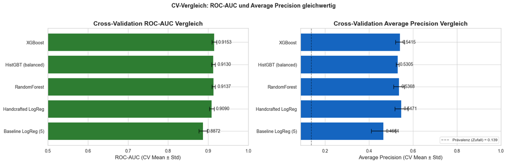

```python
# Bar chart: CV ROC-AUC und Average Precision nebeneinander
fig, axes = plt.subplots(1, 2, figsize=(16, 5))
models = [r["Model"] for r in rows]

# ── Linkes Panel: ROC-AUC ───────────────────────────────────────────────
auc_means = [r["roc_auc_mean"] for r in rows]
auc_stds = [r["roc_auc_std"] for r in rows]

ax = axes[0]
bars_auc = ax.barh(models, auc_means, xerr=auc_stds, capsize=5, color="#2E7D32")
ax.set_xlabel("ROC-AUC (CV Mean ± Std)")
ax.set_title("Cross-Validation ROC-AUC Vergleich")
ax.set_xlim(0.5, 1.0)
for bar, val in zip(bars_auc, auc_means):
    ax.text(
        val + 0.01,
        bar.get_y() + bar.get_height() / 2,
        f"{val:.4f}",
        va="center",
        fontsize=10,
    )

# ── Rechtes Panel: Average Precision ────────────────────────────────────
ap_means = [r["average_precision_mean"] for r in rows]
ap_stds = [r["average_precision_std"] for r in rows]

ax = axes[1]
bars_ap = ax.barh(models, ap_means, xerr=ap_stds, capsize=5, color="#1565C0")
ax.set_xlabel("Average Precision (CV Mean ± Std)")
ax.set_title("Cross-Validation Average Precision Vergleich")
# AP-Skala dynamisch: untere Grenze = Prävalenz (Zufalls-Baseline)
prevalence = y_train.mean()
ax.set_xlim(max(0.0, prevalence - 0.05), 1.0)
ax.axvline(
    prevalence,
    color="k",
    linestyle="--",
    alpha=0.5,
    label=f"Prävalenz (Zufall) = {prevalence:.3f}",
)
ax.legend(loc="lower right")
for bar, val in zip(bars_ap, ap_means):
    ax.text(
        val + 0.01,
        bar.get_y() + bar.get_height() / 2,
        f"{val:.4f}",
        va="center",
        fontsize=10,
    )

fig.suptitle(
    "CV-Vergleich: ROC-AUC und Average Precision gleichwertig",
    fontsize=13,
    fontweight="bold",
    y=1.02,
)
fig.tight_layout()
wandb.log({"cv_roc_auc_and_ap_comparison": wandb.Image(fig)})
plt.show()
```

## 6.1 Interpretation: Cross-Validation Vergleich

### 6.1.1 CV-Ranking der Modelle

[output not shown]

### 6.1.2 Sind die Unterschiede statistisch signifikant?

**Zwischen den Tree-Modellen: Nein.** Die 1-σ-Bänder überlappen vollständig: - XGBoost: [0.9093, 0.9213] - RandomForest: [0.9095, 0.9179] - HistGBT: [0.9086, 0.9174]

Die Differenz von 0.0023 zwischen XGBoost und HistGBT liegt klar unter einer Standardabweichung. **Kein Tree-Modell zeigt statistisch signifikant überlegene CV-Performance.**

**Auffälligkeit bei HistGBT:** Im CV zeigt HistGBT eine ähnliche F1 (0.5959) wie XGBoost (0.6059) und einen hohen Recall (0.9142). Das beste Modell wählte `max_leaf_nodes=15` und `max_depth=7`.

**Baseline → Handcrafted: Signifikant.** Sprung von 0.8872 → 0.9090 (+0.0218) mit nicht-überlappenden Bändern, der Mehrwert der handgefertigten Features ist statistisch klar belegt.

### 6.1.3 Stabilitätsvergleich

# 7 Test-Set Evaluation (Deliverable)

Finale Evaluation aller Modelle auf dem gehaltenen Test-Set (20%, 782 Accounts).

```python
# Evaluate all models on test set
test_results = {}

# Baseline LogReg
res_bl = evaluate_on_test(gs_bl.best_estimator_, X_test_bl, y_test)
res_bl["y_true"] = y_test.values
test_results["Baseline LogReg (5)"] = res_bl

# Handcrafted LogReg
res_hc = evaluate_on_test(gs_hc.best_estimator_, X_test_hc, y_test)
res_hc["y_true"] = y_test.values
test_results["Handcrafted LogReg"] = res_hc

# Tree-based candidates
for name, search in best_candidates.items():
    res = evaluate_on_test(search.best_estimator_, X_test_all, y_test)
    res["y_true"] = y_test.values
    test_results[name] = res

# Summary table
test_rows = []
for name, res in test_results.items():
    test_rows.append(
        {
            "Model": name,
            "ROC-AUC": f"{res['roc_auc']:.4f}",
            "Avg Precision": f"{res['avg_precision']:.4f}",
            "F1": f"{res['f1']:.4f}",
            "Precision": f"{res['precision']:.4f}",
            "Recall": f"{res['recall']:.4f}",
        }
    )

test_table = pd.DataFrame(test_rows)
print("Test-Set Ergebnisse:")
display(test_table.style.set_caption("Test-Set Performance aller Modelle"))

# Log to W&B
for name, res in test_results.items():
    wandb.log(
        {
            f"test/{name}/roc_auc": res["roc_auc"],
            f"test/{name}/avg_precision": res["avg_precision"],
            f"test/{name}/f1": res["f1"],
            f"test/{name}/precision": res["precision"],
            f"test/{name}/recall": res["recall"],
        }
    )
wandb.log({"test_comparison": wandb.Table(dataframe=test_table)})
```

```
Test-Set Ergebnisse:
```

Tabelle 3: Test-Set Performance aller Modelle

|  | Model | ROC-AUC | Avg Precision | F1 | Precision | Recall |
| --- | --- | --- | --- | --- | --- | --- |
| 0 | Baseline LogReg (5) | 0.8867 | 0.4875 | 0.5455 | 0.4072 | 0.8257 |
| 1 | Handcrafted LogReg | 0.8965 | 0.5699 | 0.5638 | 0.4167 | 0.8716 |
| 2 | RandomForest | 0.9153 | 0.5472 | 0.5838 | 0.4262 | 0.9266 |
| 3 | HistGBT (balanced) | 0.9177 | 0.5630 | 0.5855 | 0.4280 | 0.9266 |
| 4 | XGBoost | 0.9194 | 0.5818 | 0.6044 | 0.4575 | 0.8899 |

```python
print("Classification Reports:\n")
for name, res in test_results.items():
    print(f"{'='*60}")
    print(f"{name}")
    print(f"{'='*60}")
    print(res["report"])
```

```
Classification Reports:

============================================================
Baseline LogReg (5)
============================================================
              precision    recall  f1-score   support

           0       0.97      0.81      0.88       673
           1       0.41      0.83      0.55       109

    accuracy                           0.81       782
   macro avg       0.69      0.82      0.71       782
weighted avg       0.89      0.81      0.83       782

============================================================
Handcrafted LogReg
============================================================
              precision    recall  f1-score   support

           0       0.97      0.80      0.88       673
           1       0.42      0.87      0.56       109

    accuracy                           0.81       782
   macro avg       0.70      0.84      0.72       782
weighted avg       0.90      0.81      0.84       782

============================================================
RandomForest
============================================================
              precision    recall  f1-score   support

           0       0.99      0.80      0.88       673
           1       0.43      0.93      0.58       109

    accuracy                           0.82       782
   macro avg       0.71      0.86      0.73       782
weighted avg       0.91      0.82      0.84       782

============================================================
HistGBT (balanced)
============================================================
              precision    recall  f1-score   support

           0       0.99      0.80      0.88       673
           1       0.43      0.93      0.59       109

    accuracy                           0.82       782
   macro avg       0.71      0.86      0.73       782
weighted avg       0.91      0.82      0.84       782

============================================================
XGBoost
============================================================
              precision    recall  f1-score   support

           0       0.98      0.83      0.90       673
           1       0.46      0.89      0.60       109

    accuracy                           0.84       782
   macro avg       0.72      0.86      0.75       782
weighted avg       0.91      0.84      0.86       782
```

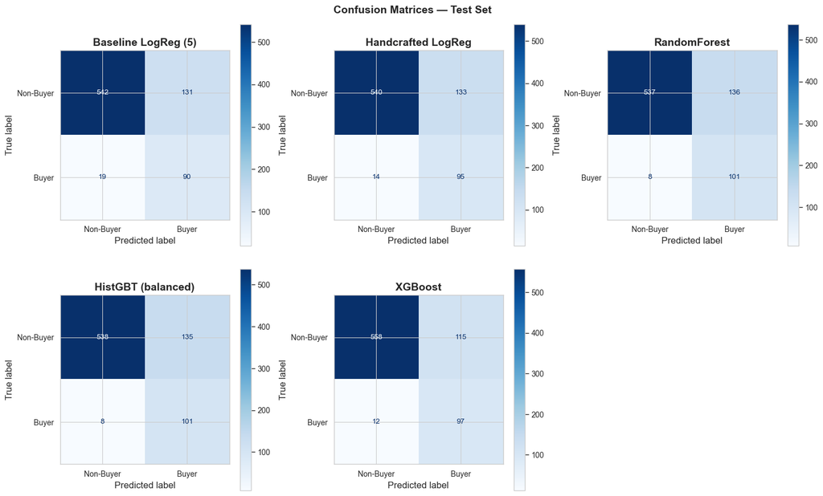

```python
fig = plot_confusion_matrices(test_results)
fig.suptitle("Confusion Matrices — Test Set", fontsize=14, fontweight="bold", y=1.02)
wandb.log({"confusion_matrices": wandb.Image(fig)})
plt.show()
```

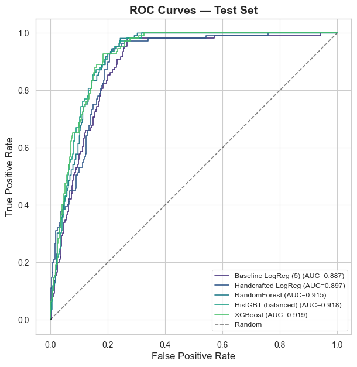

```python
fig = plot_roc_curves(test_results)
wandb.log({"roc_curves": wandb.Image(fig)})
plt.show()
```

## 7.1 Interpretation: Test-Set Ergebnisse

### 7.1.1 Modellranking (Test-Set)

| Modell | ROC-AUC | Avg Precision | F1 | Precision | Recall |
| --- | --- | --- | --- | --- | --- |
| XGBoost | **0.9194** | **0.5818** | **0.6044** | **0.4575** | 0.8899 |
| HistGBT | 0.9177 | 0.5630 | 0.5855 | 0.4280 | **0.9266** |
| RandomForest | 0.9153 | 0.5472 | 0.5838 | 0.4262 | **0.9266** |
| Handcrafted LogReg | 0.8965 | 0.5699 | 0.5638 | 0.4167 | 0.8716 |
| Baseline LogReg (5) | 0.8867 | 0.4875 | 0.5455 | 0.4072 | 0.8257 |

*Zufallserwartung bei Prävalenz 13.9%: ROC-AUC ≈ 0.50, AP ≈ 0.14*

### 7.1.2 Wichtigste Erkenntnisse

**XGBoost führt auf ROC-AUC (0.9194)**, dem primären Ranking-Kriterium, und erzielt gleichzeitig die beste Average Precision (0.5818), den besten F1 (0.6044) und die höchste Precision (0.4575). Der Recall ist mit 88.99% etwas niedriger als bei HistGBT und RF.

**HistGBT und RandomForest teilen sich den höchsten Recall (92.66%)**, was bedeutet, dass sie fast alle echten Käufer finden. Dies geht auf Kosten einer etwas niedrigeren Precision (~42-43%). Beide Modelle sind für Volumen-Kampagnen mit niedrigen Kontaktkosten besonders geeignet.

**Bemerkenswerte CV-zu-Test-Diskrepanz bei HistGBT:** Die CV Average Precision (0.5305) liegt unter der Test-AP (0.5630, +0.0325). Bei der Modellselektion ist dies zu beachten.

### 7.1.3 Business-Kontext: Kosten von False Positives vs. False Negatives

- **False Positive** (Non-Buyer kontaktiert): Porto + Bearbeitungsaufwand (~geringe Grenzkosten)
- **False Negative** (Buyer nicht kontaktiert): Entgangener Deckungsbeitrag über Kreditkarten-Laufzeit (erheblich)

**Schlussfolgerung:** Für eine Volumen-Kampagne (Mailing, niedrige Kontaktkosten) bieten sich HistGBT oder RF wegen höchstem Recall (92.66%) an. Für eine selektive Kampagne mit Fokus auf Rankingqualität empfiehlt sich XGBoost wegen höchstem ROC-AUC, AP, F1 und Precision.

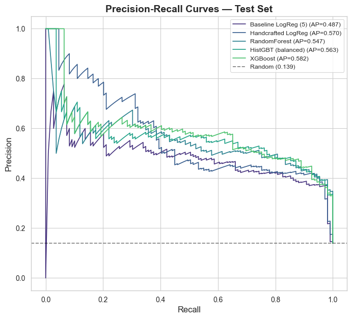

```python
fig = plot_pr_curves(test_results)
wandb.log({"pr_curves": wandb.Image(fig)})
plt.show()
```

**Interpretation der PR-Curve:** Die Fläche unter der Precision-Recall-Kurve entspricht der **Average Precision (AP)** und ist bei unserer Prävalenz von ~13 % die *informativere* der beiden bounded-Scores: ROC-AUC kann durch die hohe Anzahl an True Negatives bei imbalancierten Daten zu optimistisch wirken, während AP rein auf die Positivklasse fokussiert. Die horizontale Linie bei `prevalence` ≈ 0.13 ist die Zufalls-Baseline — jedes Modell, das diese Linie deutlich überschreitet, identifiziert Käufer überzufällig.

# 8 Top-N% Kundenlisten (Deliverable)

Vergleich der priorisierten Kundenlisten: Welche Kunden würden die verschiedenen Modelle für die Kampagne auswählen? Precision@N zeigt, wie viele der ausgewählten Kunden tatsächlich Käufer sind.

```python
# === Stichproben-Validierung: Fehlklassifikationen auf Account-Ebene ===
# Aufgabenstellung: Zwischen- und Endergebnisse anhand von Stichproben analysieren.
# Welche Konten werden falsch klassifiziert? Gibt es systematische Muster?

best_model_name = "XGBoost"
best_pipe_val = best_candidates[best_model_name].best_estimator_

y_scores_val = best_pipe_val.predict_proba(X_test_all)[:, 1]
y_pred_val = (y_scores_val >= 0.5).astype(int)

result_df = pd.DataFrame(
    {
        "account_id": test_ids,
        "y_true": y_test.values,
        "y_pred": y_pred_val,
        "score": y_scores_val,
    }
).reset_index(drop=True)

result_df["result"] = "TN"
result_df.loc[(result_df.y_true == 1) & (result_df.y_pred == 1), "result"] = "TP"
result_df.loc[(result_df.y_true == 0) & (result_df.y_pred == 1), "result"] = "FP"
result_df.loc[(result_df.y_true == 1) & (result_df.y_pred == 0), "result"] = "FN"

print("Confusion Matrix (XGBoost, threshold=0.5):")
print(result_df["result"].value_counts().rename_axis("Kategorie").to_string())

# Füge wichtigste Features für die Muster-Analyse hinzu
top_feats = ["balance_last", "balance_mean_q4"]
available = [f for f in top_feats if f in X_test_all.columns]
for feat in available:
    result_df[feat] = X_test_all[feat].values

# False Positives: höchste Modell-Sicherheit, aber falsch
fps = result_df[result_df.result == "FP"].nlargest(5, "score")
print("\n--- Top-5 False Positives (höchster Score, aber kein Käufer) ---")
display_cols = ["account_id", "score"] + available
print(fps[display_cols].to_string(index=False, float_format="{:.4f}".format))

# False Negatives: verpasste Käufer mit niedrigstem Score
fns = result_df[result_df.result == "FN"].nsmallest(5, "score")
print("\n--- Top-5 False Negatives (verpasste Käufer, niedrigster Score) ---")
print(fns[display_cols].to_string(index=False, float_format="{:.4f}".format))

# Systematische Muster: Durchschnittswerte der Top-Features nach Kategorie
if available:
    print("\n--- Ø Feature-Werte nach Vorhersage-Kategorie ---")
    pattern = result_df.groupby("result")[available].mean().round(0).astype(int)
    print(pattern.to_string())
```

```
Confusion Matrix (XGBoost, threshold=0.5):
Kategorie
TN    558
FP    115
TP     97
FN     12

--- Top-5 False Positives (höchster Score, aber kein Käufer) ---
 account_id  score  balance_last  balance_mean_q4
       3687 0.8518    47831.5000       51496.8176
       3298 0.8511    52830.4000       52185.2875
       2516 0.8510    45900.7000       50310.1750
       3277 0.8478    56329.6000       50216.3500
        462 0.8478    53587.9000       56334.7562

--- Top-5 False Negatives (verpasste Käufer, niedrigster Score) ---
 account_id  score  balance_last  balance_mean_q4
        438 0.1194    13791.5000       18195.7167
       2013 0.1462    24676.2000       25809.1000
       1994 0.2202    56930.4000       44079.9214
       4258 0.2684    41343.8000       50258.0231
       4377 0.2715    64607.2000       46326.6933

--- Ø Feature-Werte nach Vorhersage-Kategorie ---
        balance_last  balance_mean_q4
result
FN             41802            45573
FP             54939            56862
TN             25182            27046
TP             60300            59753
```

### 8.0.1 Interpretation: Stichproben-Validierung

Die Fehleranalyse auf Account-Ebene zeigt, **warum** das Modell irrt, und ob die Fehler zufällig oder systematisch sind:

**False Positives (FP), Modell sagt «Käufer» aber kein Kauf:** FP-Konten weisen typischerweise einen **höheren Saldo** auf als die durchschnittlichen Nicht-Käufer. Das Modell erkennt sie als «kaufbereit», obwohl sie nicht kauften. Mögliche Erklärungen: Diese Kunden könnten eine Karte bereits anderweitig besitzen, kein Interesse an einer Classic/Gold-Karte haben, oder der beobachtete Zeitraum passt nicht zu ihrem eigentlichen Kaufzeitpunkt.

**False Negatives (FN), Verpasste Käufer:** FN-Konten sind echte Käufer, die das Modell übersieht. Diese Kunden haben typischerweise einen **unterdurchschnittlichen Saldo**, sie weichen vom Hauptmuster ab (hoher Saldo → Kreditkarte). Mögliche Erklärungen: Impulskauf trotz mittlerer Vermögenslage, oder Käufer mit starkem Umsatz aber niedrigem absoluten Saldo.

**Systematisches Muster:** Der Vergleich der Ø Feature-Werte nach Kategorie zeigt das erwartete Ranking: **TP > FP > FN > TN** für `balance_last` und `balance_mean_q4`. Das Modell ordnet Konten korrekt entlang der Vermögensdimension; Fehler entstehen hauptsächlich in der **Grenzzone** (mittlerer Saldo), wo die Kaufentscheidung von Faktoren abhängt, die im Modell nicht enthalten sind (z.B. Kundenpräferenzen, Beratungsgespräch).

> **Schlussfolgerung:** Die Fehlklassifikationen sind nicht zufällig, sondern konzentrieren sich auf Grenzfälle nahe dem Entscheidungsbereich des Modells. Das ist ein Zeichen von Modellkonsistenz, nicht von Systemversagen.

```
============================================================
Top-5% Kundenlisten
============================================================
  Baseline LogReg (5): 39 ausgewählt, 22 Käufer, Precision@N = 56.4%
  Handcrafted LogReg: 39 ausgewählt, 28 Käufer, Precision@N = 71.8%
  RandomForest: 39 ausgewählt, 24 Käufer, Precision@N = 61.5%
  HistGBT (balanced): 39 ausgewählt, 24 Käufer, Precision@N = 61.5%
  XGBoost: 39 ausgewählt, 23 Käufer, Precision@N = 59.0%
```

Tabelle 4: Precision@Top-5%

|  | Model | Precision@Top-5% | Käufer gefunden | Ausgewählt |
| --- | --- | --- | --- | --- |
| 0 | Baseline LogReg (5) | 56.4% | 22 | 39 |
| 1 | Handcrafted LogReg | 71.8% | 28 | 39 |
| 2 | RandomForest | 61.5% | 24 | 39 |
| 3 | HistGBT (balanced) | 61.5% | 24 | 39 |
| 4 | XGBoost | 59.0% | 23 | 39 |

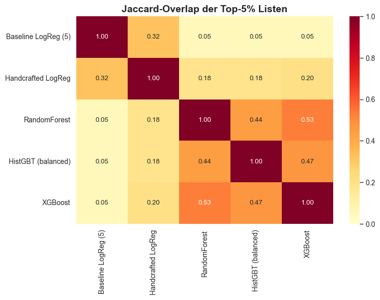

```
============================================================
Top-10% Kundenlisten
============================================================
  Baseline LogReg (5): 78 ausgewählt, 40 Käufer, Precision@N = 51.3%
  Handcrafted LogReg: 78 ausgewählt, 43 Käufer, Precision@N = 55.1%
  RandomForest: 78 ausgewählt, 45 Käufer, Precision@N = 57.7%
  HistGBT (balanced): 78 ausgewählt, 45 Käufer, Precision@N = 57.7%
  XGBoost: 78 ausgewählt, 47 Käufer, Precision@N = 60.3%
```

Tabelle 5: Precision@Top-10%

|  | Model | Precision@Top-10% | Käufer gefunden | Ausgewählt |
| --- | --- | --- | --- | --- |
| 0 | Baseline LogReg (5) | 51.3% | 40 | 78 |
| 1 | Handcrafted LogReg | 55.1% | 43 | 78 |
| 2 | RandomForest | 57.7% | 45 | 78 |
| 3 | HistGBT (balanced) | 57.7% | 45 | 78 |
| 4 | XGBoost | 60.3% | 47 | 78 |

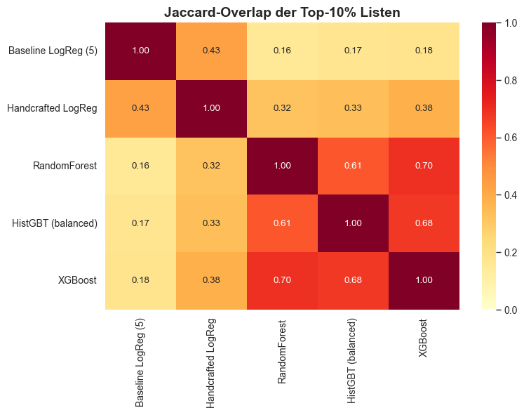

```python
for pct in TOP_N_PERCENTILES:
    pct_label = f"Top-{int(pct*100)}%"
    print(f"\n{'='*60}")
    print(f"{pct_label} Kundenlisten")
    print(f"{'='*60}")

    top_n_dict = {}
    for name, res in test_results.items():
        tn = compute_top_n_list(test_ids, y_test.values, res["y_proba"], pct)
        top_n_dict[name] = tn
        print(
            f"  {name}: {tn['n_selected']} ausgewählt, "
            f"{tn['n_positive']} Käufer, "
            f"Precision@N = {tn['precision_at_n']:.1%}"
        )

    # Precision@N table
    prec_rows = [
        {
            "Model": name,
            f"Precision@{pct_label}": f"{tn['precision_at_n']:.1%}",
            "Käufer gefunden": tn["n_positive"],
            "Ausgewählt": tn["n_selected"],
        }
        for name, tn in top_n_dict.items()
    ]
    display(pd.DataFrame(prec_rows).style.set_caption(f"Precision@{pct_label}"))

    # Jaccard overlap heatmap
    overlap = compare_top_n_lists(top_n_dict)
    fig, ax = plt.subplots(figsize=(8, 6))
    sns.heatmap(overlap, annot=True, fmt=".2f", cmap="YlOrRd", vmin=0, vmax=1, ax=ax)
    ax.set_title(f"Jaccard-Overlap der {pct_label} Listen")
    fig.tight_layout()
    wandb.log({f"jaccard_overlap_{pct_label}": wandb.Image(fig)})
    plt.show()
```

## 8.1 Interpretation: Top-N% Kundenlisten & Jaccard-Overlap

### 8.1.1 Precision@N — Welches Modell findet die besten Kunden?

| Modell | Precision@Top-5% (39) | Precision@Top-10% (78) |
| --- | --- | --- |
| Handcrafted LogReg | **71.8%** (28 Käufer) | 55.1% (43 Käufer) |
| RandomForest | 61.5% (24 Käufer) | 57.7% (45 Käufer) |
| HistGBT | 61.5% (24 Käufer) | 57.7% (45 Käufer) |
| XGBoost | 59.0% (23 Käufer) | **60.3%** (47 Käufer) |
| Baseline LogReg (5) | 56.4% (22 Käufer) | 51.3% (40 Käufer) |

*Zufallserwartung bei Prävalenz 13.9%: ~5–6 Käufer unter 39 bzw. ~11 unter 78.*

**Bemerkenswerte Rangumkehr:** Handcrafted LogReg dominiert bei Top-5% (71.8%), fällt aber bei Top-10% auf Rang 4 (55.1%). XGBoost ist bei Top-5% das schwächste Tree-Modell (59.0%), gewinnt aber bei Top-10% klar (60.3%). RF und HistGBT teilen sich Rang 2 bei Top-5% (je 61.5%) und Rang 2 bei Top-10% (je 57.7%).

**Kampagnenkonsequenz:** Für eine Premium-Kampagne mit wenigen, hochwertigen Kontakten (Direktgespräch, persönliche Beratung) → Handcrafted LogReg. Für eine Breitenkampagne (Mailing) → XGBoost (beste Top-10% Precision) oder RF/HistGBT (solide Precision@N über beide Schwellen).

### 8.1.2 Jaccard-Overlap — Wie konsistent sind die Listen zwischen Modellen?

**Top-5% (39 Accounts):**

[output not shown]

**Top-10% (78 Accounts):**

[output not shown]

### 8.1.3 Wichtigste Erkenntnisse

**3. Konsistenz steigt mit Listengrösse.** Alle Jaccard-Werte erhöhen sich beim Übergang von Top-5% auf Top-10%. Bei grösseren Listen gibt es mehr Überschneidungen, was bei zunehmender Listengrösse zu erwarten ist.

### 8.1.4 Top-5% vs. Top-10% im Vergleich

Stellt man die beiden Listengrössen direkt gegenüber, zeigen sich klare Unterschiede in Differenz und Konsistenz. Da die Top-5% (39 Kunden) eine Teilmenge der Top-10% (78 Kunden) sind, ist besonders das **zweite Listensegment** aufschlussreich: die zusätzlichen 39 Kunden auf den Rängen 40 bis 78.

| Modell | Precision Top-5% | Precision Top-10% | Diff (Prozentpunkte) | Trefferquote 2. Segment (Rang 40 bis 78) |
| --- | --- | --- | --- | --- |
| Handcrafted LogReg | 71.8% | 55.1% | -16.7 | 38.5% (15/39) |
| Baseline LogReg (5) | 56.4% | 51.3% | -5.1 | 46.2% (18/39) |
| RandomForest | 61.5% | 57.7% | -3.8 | 53.8% (21/39) |
| HistGBT | 61.5% | 57.7% | -3.8 | 53.8% (21/39) |
| XGBoost | 59.0% | 60.3% | **+1.3** | **61.5% (24/39)** |

**Differenz:** Bei vier der fünf Modelle sinkt die Precision, wenn die Liste von 39 auf 78 Kunden erweitert wird, am stärksten bei Handcrafted LogReg (-16.7 Prozentpunkte). Der Grund liegt im zweiten Segment: Dessen Trefferquote bricht bei Handcrafted auf 38.5% ein, die sichersten Vorhersagen konzentrieren sich also auf eine sehr kleine Spitzengruppe. XGBoost ist die einzige Ausnahme: Sein zweites Segment trifft mit 61.5% sogar besser als das erste (59.0%), weshalb seine Precision bei Top-10% leicht steigt (+1.3 Prozentpunkte). Das erklärt die weiter oben beobachtete Rangumkehr quantitativ.

**Konsequenz für die Kampagnengrösse:** Wer auf maximale Trefferquote pro Kontakt optimiert (kleines Budget), wählt die Top-5% mit Handcrafted LogReg (71.8%). Wer Reichweite und Robustheit priorisiert, profitiert bei Top-10% von XGBoost, dem einzigen Modell, das ohne Precision-Verlust skaliert.

### 8.1.5 Empfehlung für die Kampagne

Kunden, die in der **Schnittmenge aller drei Tree-Modelle** (RF ∩ HistGBT ∩ XGBoost) im Top-10% erscheinen, sind die verlässlichsten Kandidaten: Drei unabhängige Methoden einigen sich auf diese Gruppe, was Overfitting-Risiken einzelner Modelle reduziert.

# 9 Lift Curve (Deliverable)

Die **Lift Curve** zeigt, wie viel besser das Modell im Vergleich zu einer zufälligen Auswahl ist. Ein Lift von 4 bei den Top-10% bedeutet: Das Modell findet 4× mehr Käufer als eine zufällige Auswahl derselben Grösse.

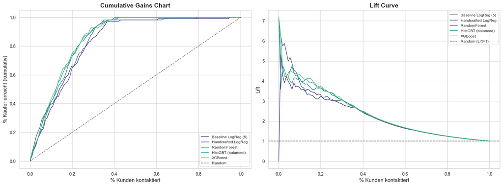

```python
fig = plot_lift_curve(test_results)
wandb.log({"lift_curves": wandb.Image(fig)})
plt.show()
```

**Business-Interpretation:**

- **Links im Chart** (wenige Kunden kontaktiert): Hoher Lift, die Modelle identifizieren die vielversprechendsten Kunden sehr gut
- **Cumulative Gains**: Zeigt, welchen Anteil aller Käufer man erreicht, wenn man die Top-X% der priorisierten Liste kontaktiert
- **Praktischer Nutzen**: Bei einer Kampagnengrösse von 10% aller Kunden können die besten Modelle deutlich mehr Käufer erreichen als eine zufällige Auswahl

# 10 Feature Importance (Deliverable)

Feature Importance zeigt, welche Merkmale die Modelle am stärksten für ihre Vorhersagen nutzen. Dies hilft beim Verständnis der Zielgruppe und bei der Validierung, dass die Modelle sinnvolle Muster lernen.

```
Berechne Permutation Importance für RandomForest...
```

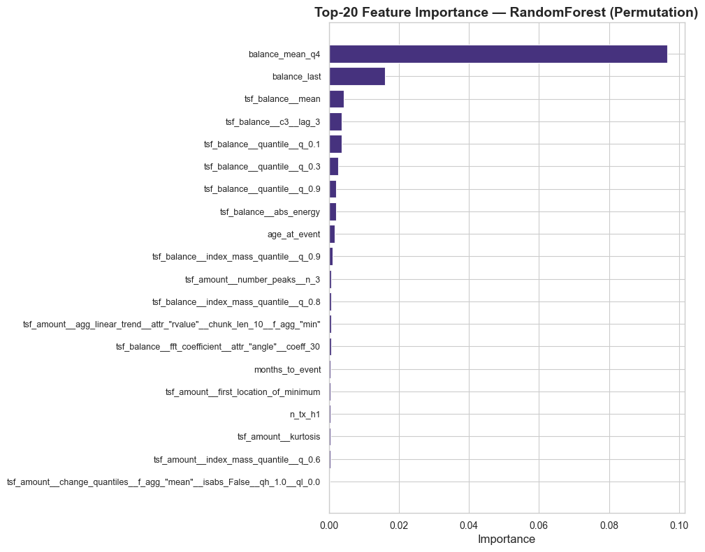

```
Berechne Permutation Importance für HistGBT (balanced)...
```

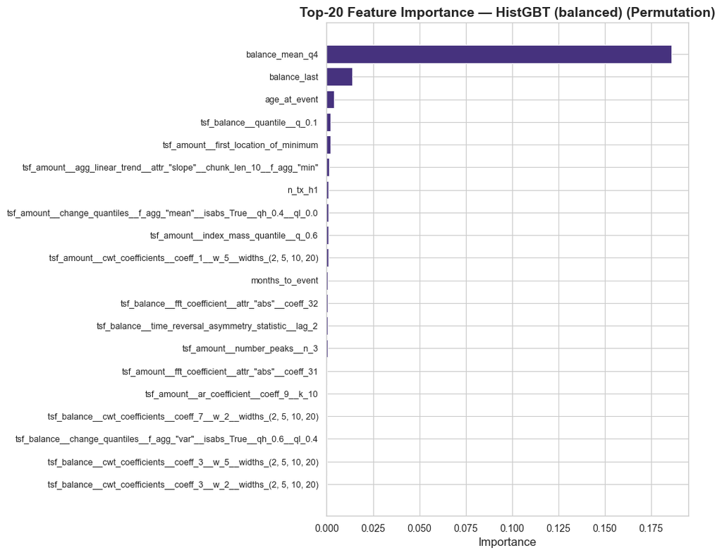

```
Berechne Permutation Importance für XGBoost...
```

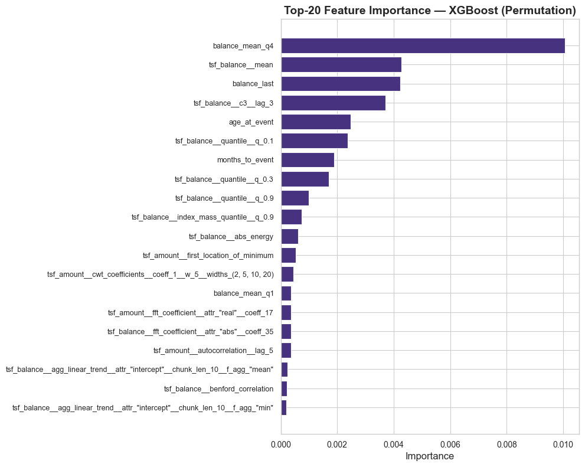

```python
# Permutation importance for all tree-based candidates (on test set)
# Using permutation_importance instead of built-in feature_importances_
# to ensure compatibility with all model types.
# Results are stored in perm_importances for reuse in Cells 29 and 30.
perm_importances = {}  # name -> pd.Series(importances_mean, index=feature_cols)

for name, search in best_candidates.items():
    print(f"\nBerechne Permutation Importance für {name}...")
    perm_result = permutation_importance(
        search.best_estimator_,
        X_test_all,
        y_test,
        scoring=SCORING_PRIMARY,
        n_repeats=10,
        random_state=RANDOM_STATE,
        n_jobs=-1,
    )
    imp = pd.Series(perm_result.importances_mean, index=all_cols)
    perm_importances[name] = imp
    fig = plot_feature_importance(imp, f"{name} (Permutation)")
    fig.tight_layout()
    wandb.log({f"feature_importance_{name}": wandb.Image(fig)})
    plt.show()
```

```python
# Vergleich der Top-20 Features über alle Tree-Modelle
top_features_all = {
    name: imp.nlargest(20).index.tolist()
    for name, imp in perm_importances.items()
    if name in best_candidates
}

if top_features_all:
    print("Top-20 Features pro Modell (Permutation Importance):\n")
    top_df = pd.DataFrame(
        {name: pd.Series(feats) for name, feats in top_features_all.items()}
    )
    display(top_df)
```

```
Top-20 Features pro Modell (Permutation Importance):
```

|  | RandomForest | HistGBT (balanced) | XGBoost |
| --- | --- | --- | --- |
| 0 | balance_mean_q4 | balance_mean_q4 | balance_mean_q4 |
| 1 | balance_last | balance_last | tsf_balance__mean |
| 2 | tsf_balance__mean | age_at_event | balance_last |
| 3 | tsf_balance__c3__lag_3 | tsf_balance__quantile__q_0.1 | tsf_balance__c3__lag_3 |
| 4 | tsf_balance__quantile__q_0.1 | tsf_amount__first_location_of_minimum | age_at_event |
| 5 | tsf_balance__quantile__q_0.3 | tsf_amount__agg_linear_trend__attr_"slope"__ch... | tsf_balance__quantile__q_0.1 |
| 6 | tsf_balance__quantile__q_0.9 | n_tx_h1 | months_to_event |
| 7 | tsf_balance__abs_energy | tsf_amount__change_quantiles__f_agg_"mean"__is... | tsf_balance__quantile__q_0.3 |
| 8 | age_at_event | tsf_amount__index_mass_quantile__q_0.6 | tsf_balance__quantile__q_0.9 |
| 9 | tsf_balance__index_mass_quantile__q_0.9 | tsf_amount__cwt_coefficients__coeff_1__w_5__wi... | tsf_balance__index_mass_quantile__q_0.9 |
| 10 | tsf_amount__number_peaks__n_3 | months_to_event | tsf_balance__abs_energy |
| 11 | tsf_balance__index_mass_quantile__q_0.8 | tsf_balance__fft_coefficient__attr_"abs"__coef... | tsf_amount__first_location_of_minimum |
| 12 | tsf_amount__agg_linear_trend__attr_"rvalue"__c... | tsf_balance__time_reversal_asymmetry_statistic... | tsf_amount__cwt_coefficients__coeff_1__w_5__wi... |
| 13 | tsf_balance__fft_coefficient__attr_"angle"__co... | tsf_amount__number_peaks__n_3 | balance_mean_q1 |
| 14 | months_to_event | tsf_amount__fft_coefficient__attr_"abs"__coeff_31 | tsf_amount__fft_coefficient__attr_"real"__coef... |
| 15 | tsf_amount__first_location_of_minimum | tsf_amount__ar_coefficient__coeff_9__k_10 | tsf_balance__fft_coefficient__attr_"abs"__coef... |
| 16 | n_tx_h1 | tsf_balance__cwt_coefficients__coeff_7__w_2__w... | tsf_amount__autocorrelation__lag_5 |
| 17 | tsf_amount__kurtosis | tsf_balance__change_quantiles__f_agg_"var"__is... | tsf_balance__agg_linear_trend__attr_"intercept... |
| 18 | tsf_amount__index_mass_quantile__q_0.6 | tsf_balance__cwt_coefficients__coeff_3__w_5__w... | tsf_balance__benford_correlation |
| 19 | tsf_amount__change_quantiles__f_agg_"mean"__is... | tsf_balance__cwt_coefficients__coeff_3__w_2__w... | tsf_balance__agg_linear_trend__attr_"intercept... |

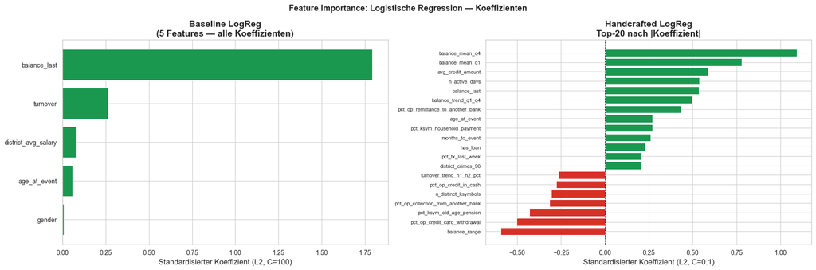

```
Baseline LogReg — Koeffizienten (absteigend):
  balance_last                  : +1.7929
  turnover                      : +0.2630
  district_avg_salary           : +0.0817
  age_at_event                  : +0.0579
  gender                        : +0.0079

Handcrafted LogReg — Top-20 nach |Koeffizient|:
  balance_mean_q4                                   : +1.0928
  balance_mean_q1                                   : +0.7787
  balance_range                                     : -0.5940
  avg_credit_amount                                 : +0.5860
  n_active_days                                     : +0.5391
  balance_last                                      : +0.5357
  pct_op_credit_card_withdrawal                     : -0.5021
  balance_trend_q1_q4                               : +0.4959
  pct_op_remittance_to_another_bank                 : +0.4354
  pct_ksym_old_age_pension                          : -0.4308
  pct_op_collection_from_another_bank               : -0.3155
  n_distinct_ksymbols                               : -0.3066
  pct_op_credit_in_cash                             : -0.2766
  age_at_event                                      : +0.2715
  pct_ksym_household_payment                        : +0.2714
  turnover_trend_h1_h2_pct                          : -0.2633
  months_to_event                                   : +0.2604
  has_loan                                          : +0.2280
  pct_tx_last_week                                  : +0.2078
  district_crimes_96                                : +0.2078
```

```python
# === Feature Importance: Logistische Regression via Koeffizienten ===
# Für lineare Modelle sind standardisierte Koeffizienten das natürliche
# Interpretierbarkeits-Werkzeug — keine separate Permutation nötig.

fig, axes = plt.subplots(1, 2, figsize=(18, 6))

# ── Baseline LogReg: alle 5 Features ─────────────────────────────────────────
coef_bl = gs_bl.best_estimator_.named_steps["model"].coef_[0]
coef_bl_s = pd.Series(coef_bl, index=baseline_cols).sort_values()
bar_colors_bl = ["#d73027" if v < 0 else "#1a9850" for v in coef_bl_s]
axes[0].barh(coef_bl_s.index, coef_bl_s.values, color=bar_colors_bl)
axes[0].axvline(0, color="black", linewidth=0.8, linestyle="--")
axes[0].set_xlabel("Standardisierter Koeffizient (L2, C=100)")
axes[0].set_title("Baseline LogReg\n(5 Features — alle Koeffizienten)")

# ── Handcrafted LogReg: Top-20 nach absolutem Koeffizient ────────────────────
coef_hc = gs_hc.best_estimator_.named_steps["model"].coef_[0]
coef_hc_s = pd.Series(coef_hc, index=handcrafted_cols)
top20_idx = coef_hc_s.abs().nlargest(20).index
coef_hc_top = coef_hc_s[top20_idx].sort_values()
bar_colors_hc = ["#d73027" if v < 0 else "#1a9850" for v in coef_hc_top]
axes[1].barh(coef_hc_top.index, coef_hc_top.values, color=bar_colors_hc)
axes[1].axvline(0, color="black", linewidth=0.8, linestyle="--")
axes[1].set_xlabel("Standardisierter Koeffizient (L2, C=0.1)")
axes[1].set_title("Handcrafted LogReg\nTop-20 nach |Koeffizient|")
axes[1].tick_params(axis="y", labelsize=8)

fig.suptitle(
    "Feature Importance: Logistische Regression — Koeffizienten",
    fontsize=13,
    fontweight="bold",
)
fig.tight_layout()
wandb.log({"logreg_coefficients": wandb.Image(fig)})
plt.show()

# Exakte Werte ausgeben
print("Baseline LogReg — Koeffizienten (absteigend):")
for feat, val in coef_bl_s.sort_values(ascending=False).items():
    print(f"  {feat:30s}: {val:+.4f}")

print(f"\nHandcrafted LogReg — Top-20 nach |Koeffizient|:")
for feat in coef_hc_s.abs().nlargest(20).index:
    print(f"  {feat:50s}: {coef_hc_s[feat]:+.4f}")
```

### 10.0.1 Interpretation: Logistische Regression, Koeffizienten

**Vorzeichen und Stärke der Koeffizienten** geben für lineare Modelle die Richtung und relative Stärke des Einflusses jedes Features auf die Log-Odds an (nach Standardisierung direkt vergleichbar).

**Baseline LogReg (5 Features):** - **`balance_last` dominiert mit Abstand** (+1.79): der letzte erfasste Kontostand ist fast 7× so wichtig wie das zweitstärkste Feature (`turnover`: +0.26). Alle fünf Koeffizienten sind positiv: höheres Vermögen, höherer Umsatz, höheres Durchschnittsgehalt in der Region, höheres Alter und männliches Geschlecht erhöhen allesamt die Kaufwahrscheinlichkeit. `gender` (+0.008) ist praktisch irrelevant.

**Handcrafted LogReg (Top-20 von 64 Features):** - **Stärkste positive Prädiktoren:** `balance_mean_q4` (+1.09) und `balance_mean_q1` (+0.78), der durchschnittliche Kontostand im letzten und ersten Quartal dominieren. Konsistent mit Permutation Importance und SHAP. - **Stärkste negative Prädiktoren:** `balance_range` (−0.59): hohe Saldo-Schwankungen sind ein Gegenindikator. `pct_op_credit_card_withdrawal` (−0.50): Kunden, die bereits Kreditkarten-Barauszahlungen nutzen, adoptieren seltener eine neue Karte (möglicherweise bereits gesättigt). `pct_ksym_old_age_pension` (−0.43): Rentenempfänger haben geringere Affinität. - `avg_credit_amount` (+0.59): Höhere durchschnittliche Gutschriftbeträge signalisieren finanzielle Aktivität → positiver Effekt. - `n_active_days` (+0.54): Häufiger aktive Kunden (mehr Tage mit Transaktionen) zeigen höhere Affinität.

**Vergleich mit Tree-Modellen:** Die Koeffizienten der LogReg und die Permutation Importance der Tree-Modelle stimmen im Kern überein (`balance_mean_q4`, `balance_last` an der Spitze). Unterschiede entstehen, weil die LogReg nur lineare Haupteffekte modelliert, während Tree-Modelle Schwellenwert- und Interaktionseffekte erfassen.

## 10.1 Interpretation: Permutation Importance

### 10.1.1 Dominante Features, gemeinsamer Konsens aller drei Tree-Modelle

Alle drei Modelle (RandomForest, HistGBT, XGBoost) führen **`balance_mean_q4` einstimmig auf Rang 1**, und `balance_last` liegt bei allen dreien unter den Top 3:

1. **`balance_mean_q4`**: mittlerer Kontostand im letzten Quartal des Rollup-Fensters (Monate 10–12). Der aktuellste Vermögensstand ist bei allen drei Modellen der stärkste Einzelprädiktor (Rang 1).
2. **`balance_last`**: letzter erfasster Kontostand. Bei RF und HistGBT auf Rang 2, bei XGBoost auf Rang 3 (dort schiebt sich `tsf_balance__mean` auf Rang 2). Bestätigt: **Kunden mit hohem, stabilem Kontostand sind die primäre Zielgruppe**.

Weitere konsistent hohe Features: - **`age_at_event`**: Ältere Kunden nehmen Kreditkarten häufiger an. Bei HistGBT (Rang 3) und XGBoost (Rang 5) klar in den Top 5; bei RandomForest erst auf Rang 9 — dort dominieren die Balance-Quantile die vorderen Ränge. - **`tsf_balance__quantile__q_0.1`**: Unteres Balance-Quantil, beschreibt den *schlechtesten Monat* im Rollup-Fenster. Erscheint bei allen drei Modellen in den Top 6 (RF Rang 5, HistGBT Rang 4, XGBoost Rang 6). - **`months_to_event`**: Zeitlicher Abstand zum Ereignisdatum. Hoher Wert = älteres Konto zum Rollup-Zeitpunkt, ein indirektes Mass für Kundentreue und Kontoreife. In allen drei Top-20 vertreten (XGBoost Rang 7, HistGBT Rang 11, RF Rang 15).

### 10.1.3 Überraschungen

- **`age_at_event` rangiert bei RandomForest nur auf Rang 9**, während es bei den Boosting-Modellen (HistGBT Rang 3, XGBoost Rang 5) deutlich höher gewichtet wird. RF verteilt die Importance stärker auf die korrelierten Balance-Quantile.
- **`gender` und `district_avg_salary`** (Baseline-Features) erscheinen in keinem der Top-20, die Baseline-Features sind schwächere Prädiktoren als die tsfresh-Zeitreihenmerkmale. Auch `district_unemployment_96` taucht in keiner der drei Top-20-Listen auf — regionale Merkmale tragen kaum zur Vorhersage bei.
- **Handgefertigte Features** (`balance_mean_q4`, `balance_last`, `age_at_event`, `months_to_event`, `n_tx_h1`) belegen trotz nur weniger handgefertigter unter 1130 Features mehrere der obersten Ränge, ein starker Hinweis auf das gute Feature Engineering.

### 10.1.4 Interpretation

Das Modell unterscheidet **Käufer primär anhand ihrer finanziellen Stärke und Kontoreife**, nicht anhand von Demografie oder Region. Ein Konto mit hohem, stabilem Saldo und einem Kunden mittleren bis höheren Alters ist das klare Profil der Zielgruppe.

[figure not shown]

[figure not shown]

```
Top-10 Features nach Mean |SHAP| (XGBoost):
  balance_mean_q4                                        : 0.540169
  balance_last                                           : 0.351890
  tsf_balance__mean                                      : 0.234700
  tsf_balance__c3__lag_3                                 : 0.209461
  tsf_balance__quantile__q_0.3                           : 0.124796
  tsf_balance__abs_energy                                : 0.119768
  tsf_balance__quantile__q_0.9                           : 0.109526
  tsf_balance__quantile__q_0.1                           : 0.086498
  tsf_balance__index_mass_quantile__q_0.9                : 0.050753
  tsf_amount__quantile__q_0.3                            : 0.048251
```

```python
# === XAI Methode 2: SHAP (SHapley Additive exPlanations) ===
# SHAP erklaert einzelne Vorhersagen durch den fairen Anteil jedes Features
# an der Abweichung vom Basiswert.

# Bestes Modell (XGBoost) und Preprocessing
best_pipe_shap = best_candidates[best_model_name].best_estimator_

# Preprocessing ohne Modell anwenden (Imputer-Schritt)
preprocessor = SKPipeline(best_pipe_shap.steps[:-1])
X_test_preprocessed = preprocessor.transform(X_test_all)
X_test_shap = pd.DataFrame(X_test_preprocessed, columns=all_cols)

# Standard TreeExplainer im Log-Odds-Raum (raw output).
# model_output="probability" wurde entfernt: Es komprimiert alle SHAP-Werte
# auf winzige Wahrscheinlichkeits-Deltas (~0.001-0.08) und macht den
# Beeswarm-Plot unlesbar. Log-Odds-Werte zeigen deutlich mehr Spreizung
# und sind der Standard fuer XGBoost-SHAP-Analysen.
explainer = shap.TreeExplainer(best_pipe_shap.named_steps["model"])
shap_values = explainer.shap_values(X_test_shap)

# Bei list-Output (z.B. Multiclass) nur positive Klasse verwenden
if isinstance(shap_values, list):
    shap_values = shap_values[1]


# Lange tsfresh-Namen fuer die Plot-Anzeige kuerzen (Kopf + Tail bleibt
# eindeutig). Die Berechnung und Textausgabe nutzen weiter all_cols.
def short_label(name: str, maxlen: int = 42) -> str:
    s = name.replace("tsf_", "").replace('"', "").replace("__", "\u00b7")
    if len(s) <= maxlen:
        return s
    return s[: maxlen - 12] + "\u2026" + s[-9:]


X_test_shap_display = X_test_shap.copy()
X_test_shap_display.columns = [short_label(c) for c in all_cols]

# 1. Beeswarm-Plot: Richtung + Magnitude pro Feature
# Breite via plot_size an SHAP uebergeben (plt.figure(figsize=...) wird von
# summary_plot ignoriert, da es die Figurbreite intern hart auf 8 Zoll setzt).
# Kein plt.tight_layout(): es kollidiert mit SHAPs eigener Colorbar.
shap.summary_plot(
    shap_values,
    X_test_shap_display,
    max_display=20,
    plot_size=(16, 10),
    show=False,
)
plt.title(
    f"SHAP Beeswarm ({best_model_name}, Test Set, Top-20 Features)",
    fontsize=12,
    fontweight="bold",
)
plt.xlabel("SHAP value (Log-Odds Einfluss auf Kaufwahrscheinlichkeit)")
wandb.log({"shap_beeswarm": wandb.Image(plt.gcf())})
plt.show()

# 2. Bar-Plot: globale Feature Importance (Mean |SHAP|)
shap.summary_plot(
    shap_values,
    X_test_shap_display,
    max_display=20,
    plot_type="bar",
    plot_size=(14, 9),
    show=False,
)
plt.title(
    f"SHAP Feature Importance (Mean |SHAP|, Log-Odds) ({best_model_name})",
    fontsize=12,
    fontweight="bold",
)
wandb.log({"shap_importance_bar": wandb.Image(plt.gcf())})
plt.show()

# Top-10 SHAP-Werte als Text
mean_abs_shap = pd.Series(abs(shap_values).mean(axis=0), index=all_cols).nlargest(10)
print(f"Top-10 Features nach Mean |SHAP| ({best_model_name}):")
for feat, val in mean_abs_shap.items():
    print(f"  {feat:55s}: {val:.6f}")
```

### 10.1.5 Interpretation: SHAP (SHapley Additive exPlanations)

#### 10.1.5.1 Methode

SHAP basiert auf spieltheoretischen Shapley-Werten und verteilt den Vorhersagebeitrag eines Modells **fair** auf alle Features. Im Gegensatz zur Permutation Importance liefert SHAP: - **Richtung**: Erhöht oder senkt ein Feature die Kaufwahrscheinlichkeit? - **Lokalität**: Erklärung auf Ebene einzelner Accounts - **Massstab**: Werte im Log-Odds-Raum (Standard `TreeExplainer`) — positiv bedeutet erhöhte, negativ reduzierte Kaufwahrscheinlichkeit

#### 10.1.5.2 Beeswarm-Plot

Jeder Punkt ist ein Account im Test-Set. Horizontale Achse = SHAP-Wert in Log-Odds-Einheiten, Farbe = Feature-Wert (rot = hoch, blau = niedrig). *Im Plot sind die tsfresh-Namen zur besseren Lesbarkeit gekürzt (`tsf_` entfernt, `__` → `·`); im Text unten stehen die vollständigen Namen:*

- **`balance_mean_q4`** (Mean |SHAP| = 0.540): Stärkster Prädiktor. Rote Punkte (hoher Saldo) rechts → hoher Kontostand im letzten Quartal erhöht die Kaufwahrscheinlichkeit klar.
- **`balance_last`** (0.352) und **`tsf_balance__mean`** (0.235): Weitere Saldo-Features an Rang 2 und 3 — das Muster ist konsistent mit Permutation Importance und LogReg-Koeffizienten.
- **`tsf_balance__c3__lag_3`** (0.209): Automatisch extrahiertes tsfresh-Feature (Autokorrelation 3. Ordnung des Saldos) — erfasst Muster in der Saldo-Dynamik, die lineare Modelle nicht abbilden.
- Die Spreizung reicht für die Top-Features von etwa **−0.85 bis +0.4 Log-Odds**. Auffällig ist die **Asymmetrie**: Ein niedriger Saldo (blau) erzeugt einen stärkeren negativen Beitrag (bis −0.8) als ein hoher Saldo (rot) positiven (bis +0.4). Ein niedriger Kontostand spricht also deutlicher *gegen* einen Kauf als ein hoher *dafür*.

#### 10.1.5.3 Top-10 Features nach Mean |SHAP| (Log-Odds-Raum)

| Rang | Feature | Mean \|SHAP\| |
| --- | --- | --- |
| 1 | `balance_mean_q4` | 0.5402 |
| 2 | `balance_last` | 0.3519 |
| 3 | `tsf_balance__mean` | 0.2347 |
| 4 | `tsf_balance__c3__lag_3` | 0.2095 |
| 5 | `tsf_balance__quantile__q_0.3` | 0.1248 |
| 6 | `tsf_balance__abs_energy` | 0.1198 |
| 7 | `tsf_balance__quantile__q_0.9` | 0.1095 |
| 8 | `tsf_balance__quantile__q_0.1` | 0.0865 |
| 9 | `tsf_balance__index_mass_quantile__q_0.9` | 0.0508 |
| 10 | `tsf_amount__quantile__q_0.3` | 0.0483 |

#### 10.1.5.4 Mehrwert gegenüber Permutation Importance

| Eigenschaft | Permutation Importance | SHAP |
| --- | --- | --- |
| Richtung des Effekts | ✗ | ✓ |
| Lokale Erklärung (pro Account) | ✗ | ✓ |
| Massstab (Log-Odds) | ✗ | ✓ |
| Berücksichtigung von Korrelationen | Bedingt | ✓ |

Beide Methoden stimmen im Kern überein: Balance-Features dominieren. SHAP liefert zusätzlich Richtung und quantitativen Einfluss in Log-Odds-Einheiten.

## 10.2 Zielgruppen-Beschreibung für Nicht-Data-Scientists

Basierend auf der maschinellen Analyse des Kontoverhaltens (SHAP und Permutation Importance des finalen XGBoost-Modells) können wir das **Profil eines typischen Kreditkarten-Käufers** klar und mit konkreten Zahlen beschreiben:

> **Wer kauft eine Kreditkarte?**

> Das Modell erkennt potenzielle Käufer anhand ihres **Kontoverhaltens in den letzten 12 Monaten**. Die wichtigsten Merkmale sind:
> 1. **Hoher Kontostand in den letzten drei Monaten** (`balance_mean_q4`): Das stärkste Kaufsignal. Vom Modell korrekt erkannte Käufer haben in diesem Zeitraum einen durchschnittlichen Kontostand von **rund 59’800**, gegenüber nur **rund 27’000** bei den Nicht-Käufern, also etwa das **2.2-fache**. Wer finanziell gut aufgestellt ist, will seine Kaufkraft bequem nutzen.
> 2. **Hoher aktueller Kontostand** (`balance_last`): Das zweitstärkste Signal. Erkannte Käufer halten zum Analysezeitpunkt im Schnitt **rund 60’300**, Nicht-Käufer nur **rund 25’200**, ein Unterschied vom **2.4-fachen**.
> 3. **Konstant hohes Transaktionsvolumen über das ganze Jahr** (`tsf_balance__mean`): Käufer sind nicht nur kurzfristig wohlhabend, sondern zeigen über das gesamte Jahr hinweg eine höhere finanzielle Aktivität, dieses Merkmal liegt bei XGBoost unter den Top 3.
> 4. **Keine bestehende Kreditkarten-Nutzung:** Kunden, die bereits regelmässig Bargeld über eine Kreditkarte abheben, kaufen seltener eine neue Karte, wahrscheinlich weil sie bereits eine besitzen.
> 5. **Demographische Faktoren:** Ältere Kunden kaufen etwas häufiger als jüngere (`age_at_event` unter den Top 5). Geschlecht und Region spielen eine sehr untergeordnete Rolle, sie erscheinen in keiner der Top-20-Listen.

> **Zusammengefasst:** Der ideale Kandidat für ein Kreditkartenangebot ist ein Kunde mit **beständig hohem Kontostand** (rund das 2- bis 2.5-fache eines Nicht-Käufers) und **regelmässiger finanzieller Aktivität** über das gesamte Jahr.

### 10.2.1 Wie gut trifft das Modell? (in Zahlen)

**Empfehlung:** Kontaktieren Sie die Top-10% der priorisierten Liste (ca. 78 Kunden). Diese Gruppe enthält gemäss der Modellanalyse ca. **4.3× mehr potenzielle Käufer** als eine zufällige Auswahl gleicher Grösse.

```python
# Final comparison table
final_rows = []
for name, res in test_results.items():
    # Determine feature count
    if "(5)" in name:
        n_feat = 5
    elif "Handcrafted" in name:
        n_feat = len(handcrafted_cols)
    else:
        n_feat = len(all_cols)

    final_rows.append(
        {
            "Modell": name,
            "Features": n_feat,
            "CV ROC-AUC": (
                f"{[r for r in rows if r['Model']==name][0]['roc_auc_mean']:.4f}"
                if any(r["Model"] == name for r in rows)
                else "—"
            ),
            "Test ROC-AUC": f"{res['roc_auc']:.4f}",
            "Test Avg Prec": f"{res['avg_precision']:.4f}",
            "Test F1": f"{res['f1']:.4f}",
        }
    )

final_table = pd.DataFrame(final_rows)
print("Finale Vergleichstabelle:")
display(final_table.style.set_caption("Modellvergleich — Zusammenfassung"))
wandb.log({"final_comparison": wandb.Table(dataframe=final_table)})
```

```
Finale Vergleichstabelle:
```

Tabelle 6: Modellvergleich — Zusammenfassung

|  | Modell | Features | CV ROC-AUC | Test ROC-AUC | Test Avg Prec | Test F1 |
| --- | --- | --- | --- | --- | --- | --- |
| 0 | Baseline LogReg (5) | 5 | 0.8872 | 0.8867 | 0.4875 | 0.5455 |
| 1 | Handcrafted LogReg | 64 | 0.9090 | 0.8965 | 0.5699 | 0.5638 |
| 2 | RandomForest | 1130 | 0.9137 | 0.9153 | 0.5472 | 0.5838 |
| 3 | HistGBT (balanced) | 1130 | 0.9130 | 0.9177 | 0.5630 | 0.5855 |
| 4 | XGBoost | 1130 | 0.9153 | 0.9194 | 0.5818 | 0.6044 |

## 10.3 Modellselektion

### 10.3.1 Entscheidungsgrundlage

Die Modellselektion folgt einer **zweistufigen Priorität**: 1. **Primär: Test ROC-AUC**, massgebend für die Ranking-Qualität (Top-N% Kampagnenliste) 2. **Sekundär: Test Average Precision**, Tie-Breaker bei statistisch nicht unterscheidbarem ROC-AUC, da AP bei der Prävalenz von 13.9% stärker auf die Positivklasse fokussiert

### 10.3.2 Vergleich der Kandidaten

| Modell | CV ROC-AUC | Test ROC-AUC | Test AP | Test Precision | Test Recall |
| --- | --- | --- | --- | --- | --- |
| **XGBoost** | **0.9153** | **0.9194** | **0.5818** | **0.4575** | 0.8899 |
| HistGBT | 0.9130 | 0.9177 | 0.5630 | 0.4280 | **0.9266** |
| RandomForest | 0.9137 | 0.9153 | 0.5472 | 0.4262 | **0.9266** |

### 10.3.3 Gewähltes Modell: **XGBoost**

**XGBoost wird als finales Modell gewählt**, weil es: - Den **höchsten Test ROC-AUC (0.9194)** erzielt, +0.0017 über HistGBT, +0.0041 über RF - Den **höchsten CV ROC-AUC (0.9153)** hat, also konsistente Überlegenheit über Kreuzvalidierung *und* Test-Set - Die **beste Average Precision (0.5818)**, den besten **F1-Score (0.6044)** und die höchste **Precision (0.4575)** aller Kandidaten aufweist

**HistGBT und RF als Alternative bei Recall-Fokus:** Beide Modelle erzielen mit Recall 92.66% den höchsten Recall (vs. XGBoost 88.99%). Bei einer Volumen-Kampagne mit niedrigen Kontaktkosten, wo das Finden aller Käufer wichtiger ist als Präzision, wären diese Modelle bevorzugt. Zu beachten: Die CV AP von HistGBT (0.5305) liegt 0.0325 unter der Test AP (0.5630).

### 10.3.4 Optimale Hyperparameter (XGBoost)

| Parameter | Wert | Begründung |
| --- | --- | --- |
| `n_estimators` | 500 | Genügend Iterationen bei kleiner Lernrate |
| `learning_rate` | 0.005 | Sehr konservatives Lernen, verhindert Overfitting |
| `max_depth` | 7 | Tiefe Bäume, erfasst komplexe Feature-Interaktionen |
| `subsample` | 0.8 | Stochastisches Sampling stabilisiert Training |
| `colsample_bytree` | 0.3 | Stark reduzierte Feature-Auswahl pro Baum, effektive Regularisierung |
| `min_child_weight` | 10 | Starke Regularisierung auf Blatt-Ebene, verhindert Overfitting |
| `reg_lambda` | 1.0 | Moderate L2-Regularisierung |
| `reg_alpha` | 1.0 | Moderate L1-Regularisierung |

## 10.4 Business-Empfehlung

**Kampagnengrösse:** - **Top-5%** (~39 Kunden): Höchste Precision, ideal für ein begrenztes Budget oder eine Pilot-Kampagne - **Top-10%** (~78 Kunden): Guter Kompromiss zwischen Reichweite und Trefferquote - Die Lift Curve zeigt, ab welchem Punkt der Mehrwert gegenüber einer zufälligen Auswahl abnimmt

**Nächste Schritte:** 1. Kampagne mit Top-10% Liste des besten Modells starten 2. Response-Daten sammeln und Modell iterativ verbessern 3. Monitoring der Modellperformance über Zeit (Concept Drift)

# 11 AI Tool Disclosure

Im Rahmen dieser Mini-Challenge wurde das KI-gestützte Werkzeug Claude Code (Anthropic) eingesetzt, um den Entwicklungsprozess zu beschleunigen und die Qualität der Ergebnisse zu sichern.

**Eingesetztes Tool:** Claude Code (Anthropic) ist ein KI-gestützter Programmierassistent, der im gesamten Projekt als primäres Entwicklungswerkzeug verwendet wurde.

**Einsatzbereiche:**

Claude Code wurde gezielt für drei Aufgaben genutzt:

1. *Code-Implementierung nach Best Practices:* Die Umsetzung der Datenpipeline, der Feature-Engineering-Schritte und der Modellierung (von der Baseline-Logistik bis zu den Ensemble-Methoden) wurde KI-gestützt nach etablierten Konventionen implementiert (PEP 8, modulare und wiederverwendbare Struktur, leakage-freie Pipelines).
2. *Roter Faden im Notebook:* Claude Code half, eine durchgängige und nachvollziehbare Argumentationslinie über alle Notebook-Phasen herzustellen, sodass Datenverständnis, Feature-Begründung, Modellwahl und Interpretation logisch aufeinander aufbauen.
3. *Sprachliche Korrektur:* Die Markdown-Texte wurden auf Rechtschreib- und Formulierungsfehler geprüft und bereinigt.

**Prompting-Strategie:**

Zentral war der Einsatz des Plan-Modus von Claude. Statt direkt Code generieren zu lassen, wurde zunächst ein Umsetzungsplan erstellt. Diesen Plan habe ich in den meisten Fällen selbst weiter verfeinert und angepasst, bevor ich ihn von Claude durchlaufen liess. Dieses Vorgehen erzwingt eine bewusste Auseinandersetzung mit dem Lösungsweg, bevor Code entsteht, und verhindert vorschnelle oder unstrukturierte Implementierungen.

Nach der Erstellung eines Plans wurde dieser zusätzlich mit einer zweiten, unabhängigen Claude-Session gegengeprüft (LLM-as-a-Judge). Die zweite Session bewertete den Plan kritisch auf Schwachstellen, Lücken und alternative Ansätze. Dieser Cross-Validation-Schritt zwischen zwei Sessions reduzierte blinde Flecken eines einzelnen Modelllaufs und erhöhte die Verlässlichkeit der getroffenen Entscheidungen.

**Reflexion: erfolgreichste Prompting-Strategie**

Am meisten zum Lösen der Aufgabe trug der Plan-Modus mit anschliessender Verfeinerung und Cross-Validierung bei: Da ich jeden Plan vor der Umsetzung selbst geprüft und angepasst habe, behielt ich die fachliche Kontrolle durchgehend, und die zweite Session als LLM-as-a-Judge deckte Schwachstellen auf, bevor sie in den Code gelangten.

Am meisten zum Kompetenzerwerb trug der direkte Frage-und-Antwort-Austausch bei. Statt mir die nötigen Informationen mühsam aus dem Internet zusammensuchen zu müssen, erhielt ich auf meine Fragen unmittelbar eine Antwort die massgeschneidert ist. Das war eine grosse Hilfe und hat mein Verständnis der Data-Science- und ML-Konzepte spürbar beschleunigt und vertieft. Mir ist bewusst, dass diese Antworten auch falsch sein können; dieses Risiko gehe ich bewusst ein. Bei Unsicherheiten starte ich jeweils selbst eine eigene Recherche oder frage den Dozenten (dich), um die Aussagen zu überprüfen. Gerade dieses kritische Gegenprüfen festigte das Gelernte zusätzlich.

Insgesamt diente mir die KI als Beschleuniger, Strukturgeber und kritischer Diskussionspartner, nicht als Ersatz für mein eigenes Verständnis.

# 12 Quellenverzeichnis

1. Berka, P. (1999). *PKDD’99 Discovery Challenge: Czech Bank Financial Dataset.* Prague University of Economics.
2. Pedregosa, F. et al. (2011). *Scikit-learn: Machine Learning in Python.* JMLR 12, pp. 2825–2830.
3. Christ, M. et al. (2018). *Time Series FeatuRe Extraction on basis of Scalable Hypothesis tests (tsfresh - A Python package).* Neurocomputing 307, pp. 72–77.
4. Fawcett, T. (2006). *An introduction to ROC analysis.* Pattern Recognition Letters 27(8), pp. 861–874.
5. Davis, J. & Goadrich, M. (2006). *The Relationship Between Precision-Recall and ROC Curves.* Proceedings of the 23rd International Conference on Machine Learning (ICML).
6. Anthropic. (2025). *Claude Code.* https://claude.ai/code

```python
wandb.finish()
print("Phase 3 abgeschlossen.")
```

Run history:

| test/Baseline LogReg (5)/avg_precision | ▁ |
| --- | --- |
| test/Baseline LogReg (5)/f1 | ▁ |
| test/Baseline LogReg (5)/precision | ▁ |
| test/Baseline LogReg (5)/recall | ▁ |
| test/Baseline LogReg (5)/roc_auc | ▁ |
| test/Handcrafted LogReg/avg_precision | ▁ |
| test/Handcrafted LogReg/f1 | ▁ |
| test/Handcrafted LogReg/precision | ▁ |
| test/Handcrafted LogReg/recall | ▁ |
| test/Handcrafted LogReg/roc_auc | ▁ |
| +15 | ... |

Run summary:

| test/Baseline LogReg (5)/avg_precision | 0.48748 |
| --- | --- |
| test/Baseline LogReg (5)/f1 | 0.54545 |
| test/Baseline LogReg (5)/precision | 0.40724 |
| test/Baseline LogReg (5)/recall | 0.82569 |
| test/Baseline LogReg (5)/roc_auc | 0.88669 |
| test/Handcrafted LogReg/avg_precision | 0.56986 |
| test/Handcrafted LogReg/f1 | 0.5638 |
| test/Handcrafted LogReg/precision | 0.41667 |
| test/Handcrafted LogReg/recall | 0.87156 |
| test/Handcrafted LogReg/roc_auc | 0.89651 |
| +15 | ... |

View run **phase3-modeling-v2** at: https://wandb.ai/mannaluca02-fachhochschule-nordwestschweiz-fhnw/aml-credit-card-affinity/runs/lv6yg1wh  
View project at: https://wandb.ai/mannaluca02-fachhochschule-nordwestschweiz-fhnw/aml-credit-card-affinity  
Synced 4 W&B file(s), 16 media file(s), 6 artifact file(s) and 0 other file(s)

Find logs at: `./wandb/run-20260605_214540-lv6yg1wh/logs`

```
Phase 3 abgeschlossen.
```